# Final Assignment

Note that, for plotting in log scale, it is necessary to plot only those log-degrees and log-probabilities corresponding to degrees and probabilities larger than 0. Therefore the first step is to locate such probabilities. Then, we can make the plot in log-scale.

```r
degree_dis <- degree_distribution(g)
max_degree <- max(degree(g))
degree_dis_positive <- which(degree_dis!=0)
```

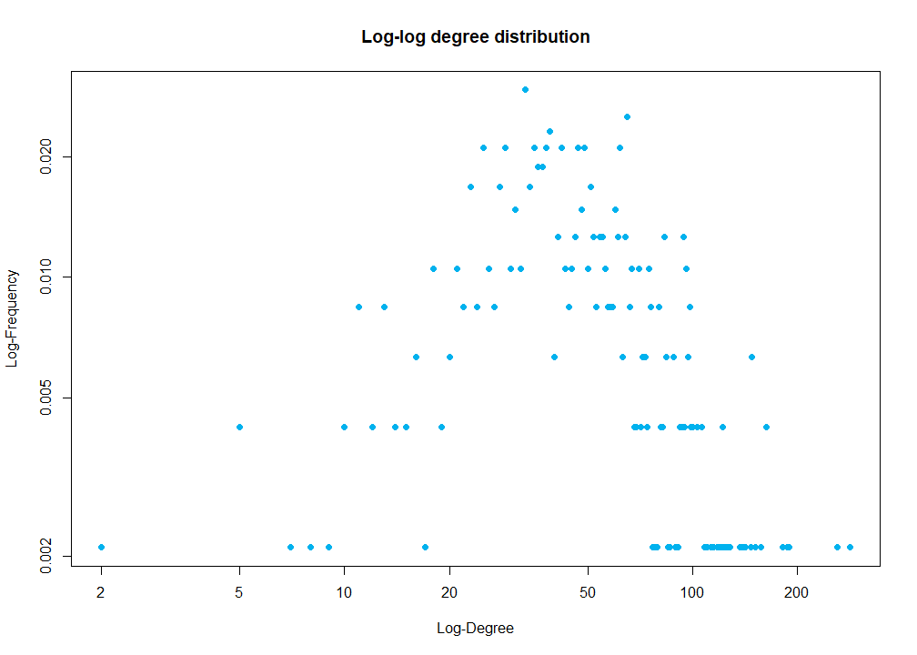

```r
plot(degree_dis_positive-1,degree_dis[degree_dis_positive],log="xy",
     col=color_1,main="Log-log degree distribution",
     xlab="Log-Degree",ylab="Log-Frequency",pch=19)
```

As we can observe, we corrected right-skewness. However, this is clearly non-linear, makes no sense to fit a linear regression. Instead of using this degree distribution we will try with in-degree and out-degree distributions and check that a linear regression is more adequate in the latter distributions.

```r
in_degree_distribution <- degree(g, mode = "in", loops = FALSE)
out_degree_distribution <- degree(g, mode = "out", loops = FALSE)
```

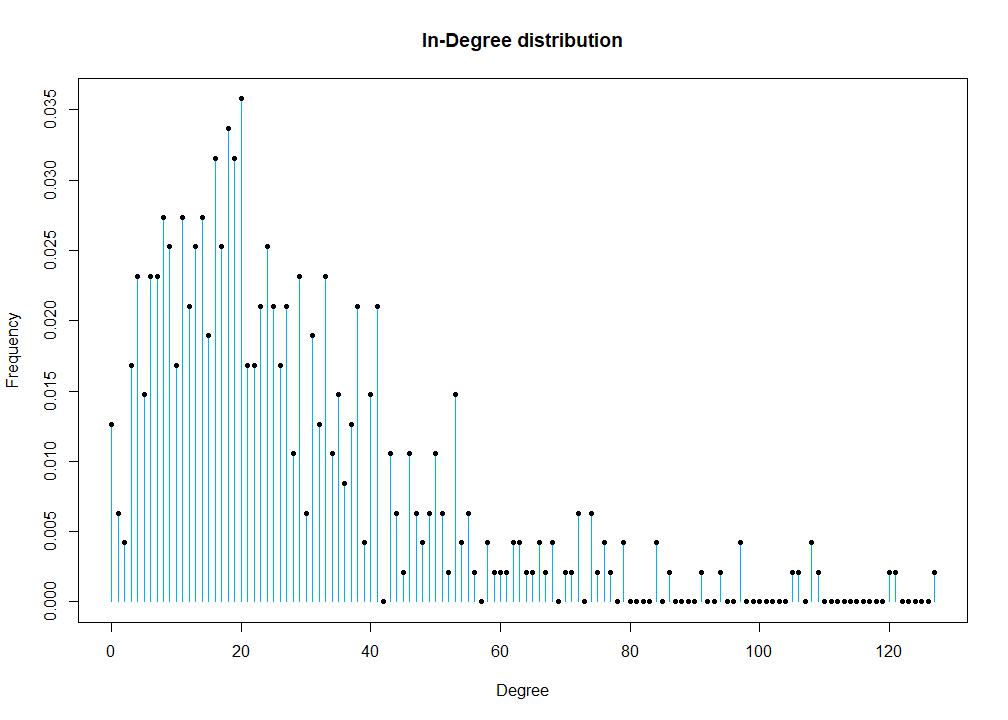

```r
color_1 <- "deepskyblue2"
par(mar=c(5,4,4,2)+0.1)
plot(0:max(degree(g, mode="in")),degree_distribution(g, mode="in"),col=color_1,
     main="In-Degree distribution",
     xlab="Degree",ylab="Frequency",type="h",lwd=1.5)
points(0:max(degree(g,mode="in")),degree_distribution(g,mode="in"),pch=20)
```

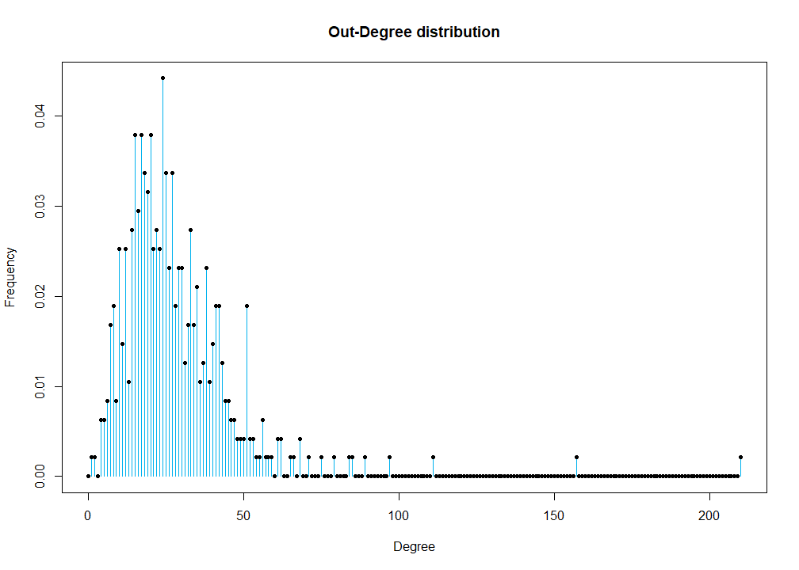

```r
color_1 <- "deepskyblue2"
par(mar=c(5,4,4,2)+0.1)
plot(0:max(degree(g, mode="out")),degree_distribution(g, mode="out"),col=color_1,
     main="Out-Degree distribution",
     xlab="Degree",ylab="Frequency",type="h",lwd=1.5)
points(0:max(degree(g,mode="out")),degree_distribution(g,mode="out"),pch=20)
```

Again both in-degree and out-degree distributions are right skewed, showing even more extreme skewness in the out-degree distribution.

```r
degree_dis_in <- degree_distribution(g,mode="in")
max_degree_in <- max(degree(g,mode="in"))
degree_dis_positive_in <- which(degree_dis_in!=0)
```

```r
degree_dis_out <- degree_distribution(g,mode="out")
max_degree_out <- max(degree(g,mode="out"))
degree_dis_positive_out <- which(degree_dis_out!=0)
```

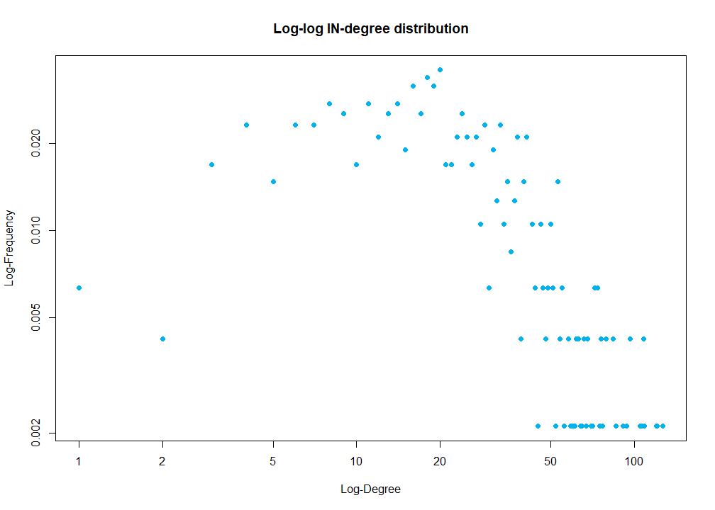

```r
plot(degree_dis_positive_in-1,degree_dis_in[degree_dis_positive_in],log="xy",
     col=color_1,main="Log-log IN-degree distribution",
     xlab="Log-Degree",ylab="Log-Frequency",pch=19)
```

Once that we have corrected skewness, we can fit a power-law to the log-degree distribution. For that, we estimate a linear regression model by Weigthed Least Squares (WLS). For that, first, we estimate a linear regression by Ordinary Least Squares (OLS).

Note that the first two values could be considered as outliers, having a large effect in the fitting, so we eliminate them.

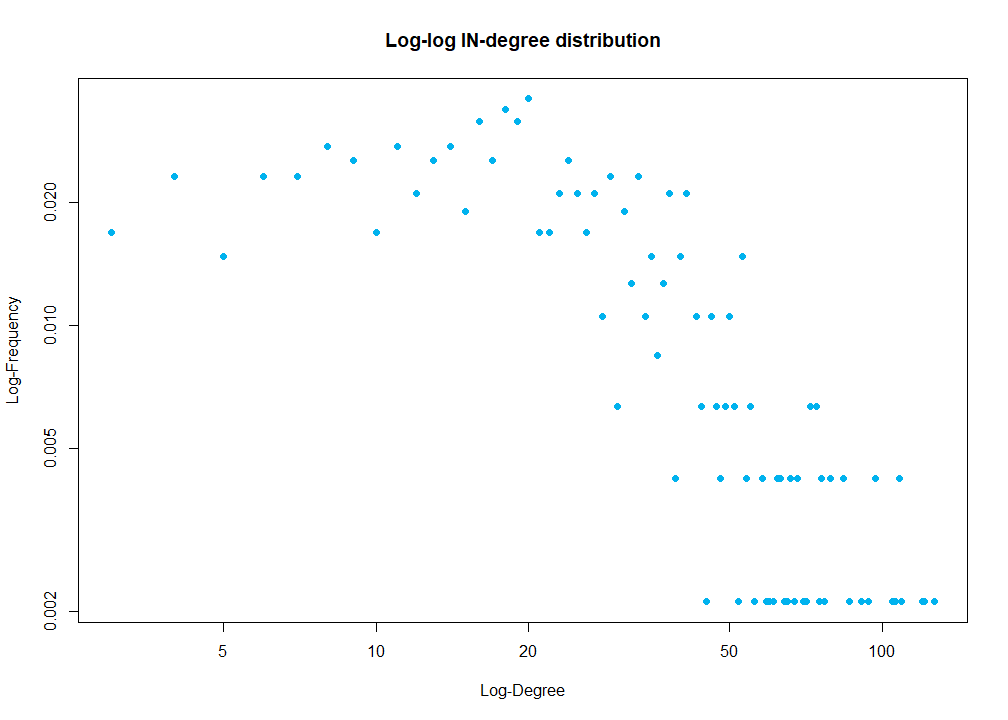

```r
plot(degree_dis_positive_in[-c(1,2,3)] - 1, degree_dis_in[degree_dis_positive_in][-c(1,2,3)], log="xy",
     col=color_1, main="Log-log IN-degree distribution",
     xlab="Log-Degree", ylab="Log-Frequency", pch=19)
```

```r
log_deg_dist_in <- log(degree_dis_in[degree_dis_positive_in])[c(-1,-2,-3)]
log_deg_in <- log(degree_dis_positive_in-1)[c(-1,-2,-3)]
first_fit_in <- lm(log_deg_dist_in~log_deg_in)
summary(first_fit_in)
```

```
##
## Call:
## lm(formula = log_deg_dist_in ~ log_deg_in)
##
## Residuals:
##      Min       1Q   Median       3Q      Max
## -1.55115 -0.43149  0.04885  0.46304  1.11159
##
## Coefficients:
##             Estimate Std. Error t value Pr(>|t|)
## (Intercept) -1.50779    0.29212  -5.161 1.68e-06 ***
## log_deg_in  -0.93294    0.07876 -11.845  < 2e-16 ***
## ---
## Signif. codes:  0 '***' 0.001 '**' 0.01 '*' 0.05 '.' 0.1 ' ' 1
##
## Residual standard error: 0.6018 on 82 degrees of freedom
## Multiple R-squared:  0.6311, Adjusted R-squared:  0.6266
## F-statistic: 140.3 on 1 and 82 DF,  p-value: < 2.2e-16
```

```r
second_fit_in <- lm(log_deg_dist_in~log_deg_in,weights=1/first_fit_in$fitted.values^2)
summary(second_fit_in)
```

```
##
## Call:
## lm(formula = log_deg_dist_in ~ log_deg_in, weights = 1/first_fit_in$fitted.values^2)
##
## Weighted Residuals:
##      Min       1Q   Median       3Q      Max
## -0.40836 -0.09346 -0.00206  0.10183  0.25245
##
## Coefficients:
##             Estimate Std. Error t value Pr(>|t|)
## (Intercept) -2.25816    0.23611  -9.564 5.45e-15 ***
## log_deg_in  -0.72040    0.06956 -10.357  < 2e-16 ***
## ---
## Signif. codes:  0 '***' 0.001 '**' 0.01 '*' 0.05 '.' 0.1 ' ' 1
##
## Residual standard error: 0.1367 on 82 degrees of freedom
## Multiple R-squared:  0.5667, Adjusted R-squared:  0.5615
## F-statistic: 107.3 on 1 and 82 DF,  p-value: < 2.2e-16
```

The obtained fitting is $\widehat{\log(p_d)}=-1.50779-0.93294\log(d)$. The coefficient of determination is $R^2=0.6311$. Secondly, we estimate the variances of the errors and then carry out WLS that lead to the fitted model $\widehat{\log(p_d)}=-2.25816-0.72040\log(d)$ with coefficient of determination $R^2=0.5667$ (worse than before). The estimated slope $\hat{\alpha}=-0.72040$. indicating a moderate decrease, which appears to confirm that while most vertices have small degrees, a few vertices have larger degrees, although not extraordinarily large. Finally, we add the regression line to the plot.

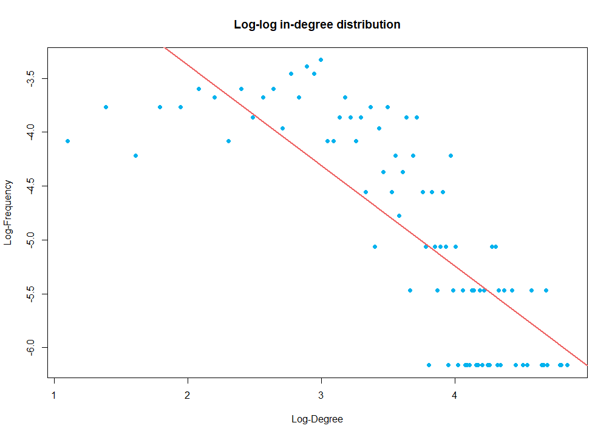

```r
color_2 <- "indianred2"
plot(log_deg_in,log_deg_dist_in,
     col=color_1,main="Log-log in-degree distribution",
     xlab="Log-Degree",ylab="Log-Frequency",pch=19)
abline(first_fit_in$coefficients[1],first_fit_in$coefficients[2],col=color_2,lwd=2)
```

We now do the same for the out-degree distribution.

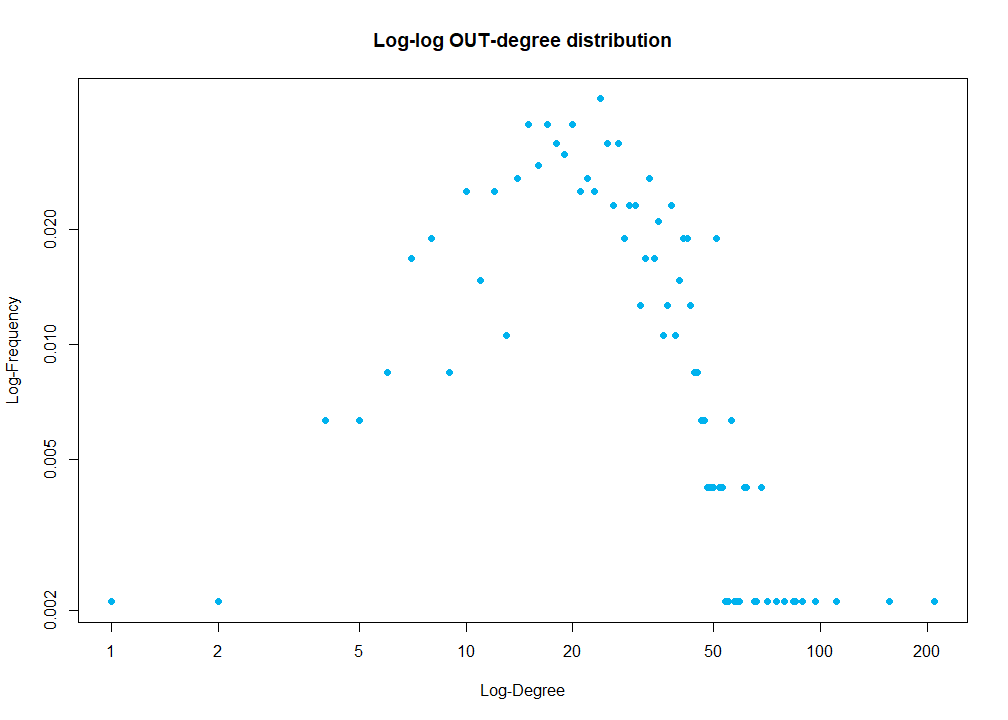

```r
plot(degree_dis_positive_out-1,degree_dis_out[degree_dis_positive_out],log="xy",
     col=color_1,main="Log-log OUT-degree distribution",
     xlab="Log-Degree",ylab="Log-Frequency",pch=19)
```

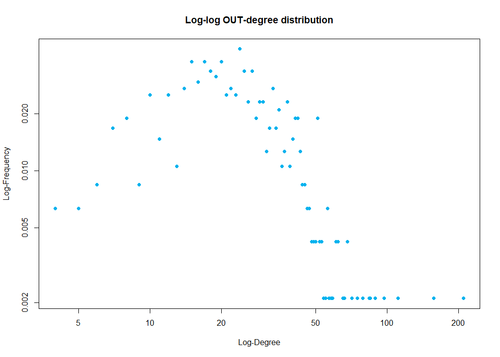

```r
plot(degree_dis_positive_out[-c(1,2)] - 1, degree_dis_out[degree_dis_positive_out][-c(1,2)], log="xy",
     col=color_1, main="Log-log OUT-degree distribution",
     xlab="Log-Degree", ylab="Log-Frequency", pch=19)
```

```r
log_deg_dist_out <- log(degree_dis_out[degree_dis_positive_out])[c(-1,-2)]
log_deg_out <- log(degree_dis_positive_out-1)[c(-1,-2)]
first_fit_out <- lm(log_deg_dist_out~log_deg_out)
summary(first_fit_out)
```

```
##
## Call:
## lm(formula = log_deg_dist_out ~ log_deg_out)
##
## Residuals:
##      Min       1Q   Median       3Q      Max
## -2.10891 -0.63357  0.06629  0.73035  1.31798
##
## Coefficients:
##             Estimate Std. Error t value Pr(>|t|)
## (Intercept)  -1.8099     0.4342  -4.168 8.75e-05 ***
## log_deg_out  -0.8266     0.1205  -6.859 2.39e-09 ***
## ---
## Signif. codes:  0 '***' 0.001 '**' 0.01 '*' 0.05 '.' 0.1 ' ' 1
##
## Residual standard error: 0.805 on 69 degrees of freedom
## Multiple R-squared:  0.4054, Adjusted R-squared:  0.3968
## F-statistic: 47.05 on 1 and 69 DF,  p-value: 2.39e-09
```

With ordinary least squares, we obtain a fitting $\widehat{\log p_d}=-1.8099+-0.8266\log(d)$ for the out-degree distribution. The coefficient of determination is $R^2=0.4054$. This is not a very good result, but in light of the non-linearity of our data, it was something we could expect.

```r
second_fit_out <- lm(log_deg_dist_out~log_deg_out,weights=1/first_fit_out$fitted.values^2)
summary(second_fit_out)
```

```
##
## Call:
## lm(formula = log_deg_dist_out ~ log_deg_out, weights = 1/first_fit_out$fitted.values^2)
##
## Weighted Residuals:
##      Min       1Q   Median       3Q      Max
## -0.51121 -0.15253 -0.01137  0.17664  0.31493
##
## Coefficients:
##             Estimate Std. Error t value Pr(>|t|)
## (Intercept)  -2.8091     0.3942  -7.125 7.89e-10 ***
## log_deg_out  -0.5371     0.1171  -4.586 1.96e-05 ***
## ---
## Signif. codes:  0 '***' 0.001 '**' 0.01 '*' 0.05 '.' 0.1 ' ' 1
##
## Residual standard error: 0.1886 on 69 degrees of freedom
## Multiple R-squared:  0.2336, Adjusted R-squared:  0.2225
## F-statistic: 21.03 on 1 and 69 DF,  p-value: 1.962e-05
```

Weighted least squares gives us the fit $\widehat{\log p_d}=-2.8091-0.5371\log(d)$. The coefficient of determination is even worse, $R^2=0.2336$. The estimated slope is $\hat{\alpha}=-0.5371$, which again is a sensible result due to the sparse nature of the network.

We fit the regression line to the plot.

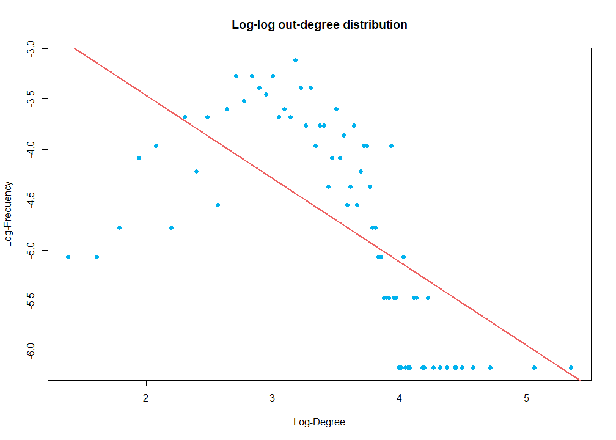

```r
color_2 <- "indianred2"
plot(log_deg_out,log_deg_dist_out,
     col=color_1,main="Log-log out-degree distribution",
     xlab="Log-Degree",ylab="Log-Frequency",pch=19)
abline(first_fit_out$coefficients[1],first_fit_out$coefficients[2],col=color_2,lwd=2)
```

### 3.5.2 Degrees and their distributions in the weighted graph

We now do this again, but taking into account the weights in the edges of our graph. Firstly, we compute the weighted degree sequence of the network, as well as the average weighted degree of the network. The strength of a vertex in a graph is defined as the sum of weights of its incident edges.

```r
head(strength(g))
```

```
##      Tammy Baldwin      John Barrasso     Michael Bennet   Marsha Blackburn
##          0.1998895          0.2453818          0.5740193          0.2770146
## Richard Blumenthal          Roy Blunt
##          0.3422145          0.2379193
```

```r
mean(strength(g))
```

```
## [1] 0.3251765
```

The average weighted degree of the network is 0.3252, which indicates that on average, a congressperson has around 0.32 weighted influence via twitter on the rest of the congresspeople.

```r
head(table(strength(g)), n = 20)
```

```
##
## 0.0226415094339623 0.0240038738240177 0.0303030303030303 0.0428015564202335
##                  1                  1                  1                  1
## 0.0467851893505431 0.0485175202156334 0.0491707206935448 0.0517164712883939
##                  1                  1                  1                  1
## 0.0566619815822638 0.0578027421665609 0.0645186308481954 0.0660765942668869
##                  1                  1                  1                  1
## 0.0673682109327181 0.0673933048848474  0.068700849826538 0.0697648405129694
##                  1                  1                  1                  1
## 0.0722693125942843 0.0758846268212905 0.0767129802135719 0.0771400083513075
##                  1                  1                  1                  1
```

In particular, the weighted degree distribution of our network is positively skewed. Indeed, the average weighted degree (0.3251765) is low compared with some of the weighted degrees that can be as high as 2.4755005.

To compute the weighted degree distribution, we have to write a function we used in class called `graph.strength.distribution` to do it because igraph does not have a function to compute such distribution.

```r
graph.strength.distribution <- function (graph, cumulative = FALSE, ...)
{
  if (!is_igraph(graph)) {
    stop("Not a graph object")
  }
  cs <- strength(graph, ...)
  breaks <- seq(min(cs), max(cs), length.out = length(cs) + 1)
  hi <- hist(cs, breaks = breaks ,plot=FALSE)$density
  if (!cumulative) {
    res <- hi
  }
  else {
    res <- rev(cumsum(rev(hi)))
  }
  res
}
```

The function begins by validating the input to ensure it’s a valid `igraph` object. If the input isn’t valid, the function stops with an error message.

Next, the function calculates the strength of each vertex in the graph and stores it in a variable called `cs`. It then computes the density of the strength values by creating a histogram without plotting it. The breaks for the histogram are determined based on the minimum and maximum strength values in `cs`.

Depending on the `cumulative` argument, the function either returns the computed density values directly or calculates the cumulative distribution of the strength values using the `cumsum` function. If `cumulative` is set to `TRUE`, the function reverses the order of the density values before calculating the cumulative sum to ensure the correct cumulative distribution is obtained.

Finally, the function returns the computed result, which is either the density values or the cumulative distribution of the strength values, based on the `cumulative` argument.

We use it in our weighted graph.

```r
weighted_degree_dis <- graph.strength.distribution(g)
head(weighted_degree_dis, n = 50)
```

```
##  [1] 0.8153750 0.4076875 0.0000000 0.4076875 0.4076875 1.2230626 0.8153750
##  [8] 0.0000000 2.0384376 0.8153750 1.6307501 2.0384376 0.4076875 2.0384376
## [15] 2.4461251 1.2230626 0.8153750 0.4076875 1.2230626 1.2230626 4.4845628
## [22] 2.8538127 1.2230626 2.0384376 1.6307501 2.4461251 2.0384376 3.6691877
## [29] 0.8153750 4.0768752 3.2615002 4.4845628 2.0384376 0.8153750 1.6307501
## [36] 1.6307501 0.4076875 3.6691877 2.0384376 3.2615002 2.8538127 3.2615002
## [43] 3.2615002 2.4461251 2.8538127 3.2615002 4.8922503 1.2230626 1.6307501
## [50] 2.0384376
```

We obtain and store the maximum degree to use it later in the plotting of the distribution.

```r
max_weighted_degree <- max(strength(g))
max_weighted_degree
```

```
## [1] 2.4755
```

Now we can obtain our plot.

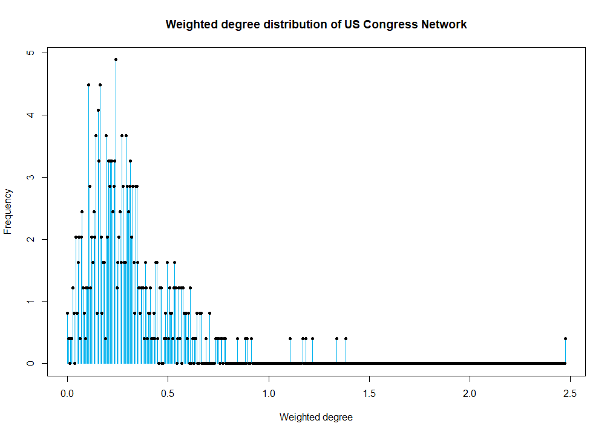

```r
par(mar=c(5,4,4,2)+0.1)
plot(seq(0, max_weighted_degree, length.out = length(weighted_degree_dis)), weighted_degree_dis,col=color_1,
     main="Weighted degree distribution of US Congress Network",
     xlab="Weighted degree",ylab="Frequency",type="h",lwd=1.5)
points(seq(0, max_weighted_degree, length.out = length(weighted_degree_dis)), weighted_degree_dis, pch=20)
```

We can see that it is right-skewed. Consequently, we plot the weighted degree distribution in log scale, i.e., plot log of the weighted degrees vs log of the probabilities (relative frequencies). As before, we plot only those log-weighted-degrees and log-probabilities corresponding to weighted degrees and probabilities larger than 0, which we obtain previously.

```r
weighted_degree_dis_positive <- which(weighted_degree_dis!=0)
weighted_degree_dis_positive
```

```
##   [1]   1   2   4   5   6   7   9  10  11  12  13  14  15  16  17  18  19  20
##  [19]  21  22  23  24  25  26  27  28  29  30  31  32  33  34  35  36  37  38
##  [37]  39  40  41  42  43  44  45  46  47  48  49  50  51  52  53  54  55  56
##  [55]  57  58  59  60  61  62  63  64  65  66  67  68  69  70  71  72  73  74
##  [73]  75  76  77  78  79  80  81  82  83  84  85  86  87  89  90  93  94  95
##  [91]  96  97  98  99 100 101 102 103 104 106 107 108 109 111 112 113 114 115
## [109] 116 118 120 122 123 124 127 128 133 136 142 143 144 145 147 148 150 151
## [127] 163 170 172 176 213 225 228 234 257 266 475
```

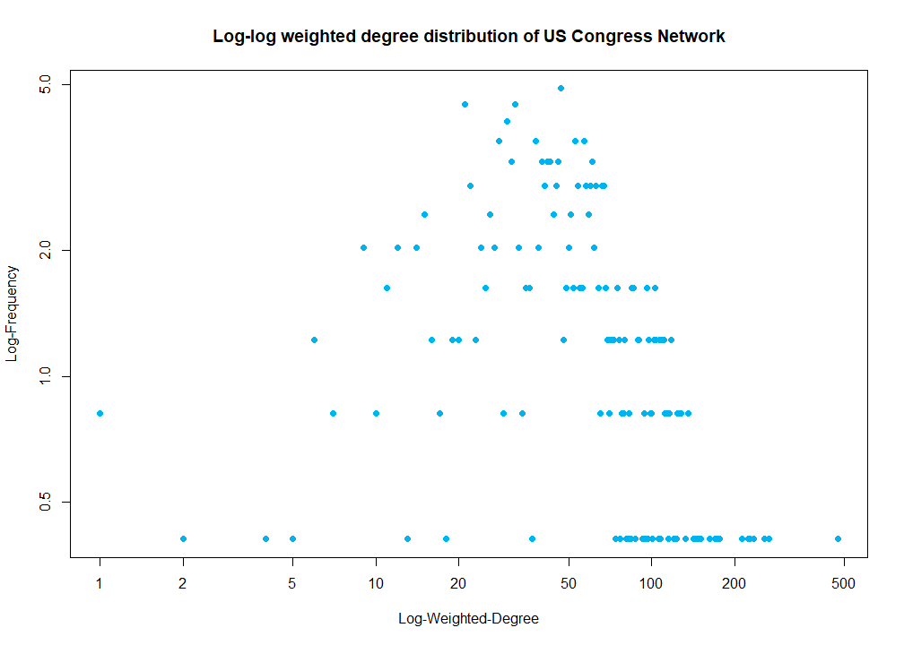

```r
plot(weighted_degree_dis_positive,
     weighted_degree_dis[weighted_degree_dis_positive],
     log="xy",col=color_1,main="Log-log weighted degree distribution of US Congress Network",
     xlab="Log-Weighted-Degree",ylab="Log-Frequency",pch=19,lwd=1.5)
```

The result is that we can see several vertices are of low degree, while another set of vertices are of higher degree. Therefore, the differences are not so large as in the unweighted case and do not follow a linear model either. We separate in the in-degree and out-degree distributions.

```r
in_degree_weighted_dis <- graph.strength.distribution(g, mode = "in")
out_degree_weighted_dis <- graph.strength.distribution(g, mode = "out")
```

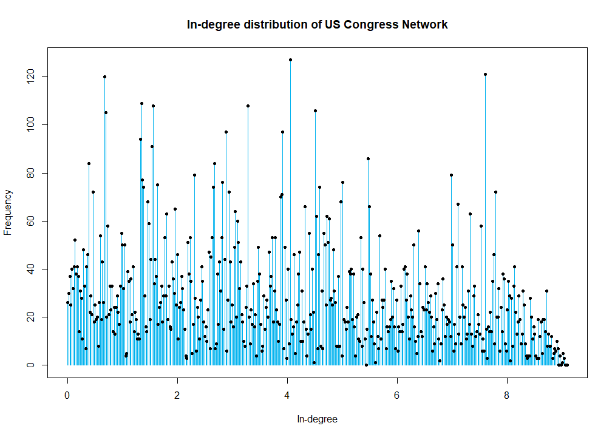

```r
par(mar=c(5,4,4,2)+0.1)
plot(seq(0, max(in_degree_weighted_dis), length.out = length(in_degree_weighted_dis)), degree(g, mode = "in"), col=color_1,
     main="In-degree distribution of US Congress Network",
     xlab="In-degree", ylab="Frequency", type="h", lwd=1.5)
points(seq(0, max(in_degree_weighted_dis), length.out = length(in_degree_weighted_dis)), degree(g, mode = "in"), pch=20)
```

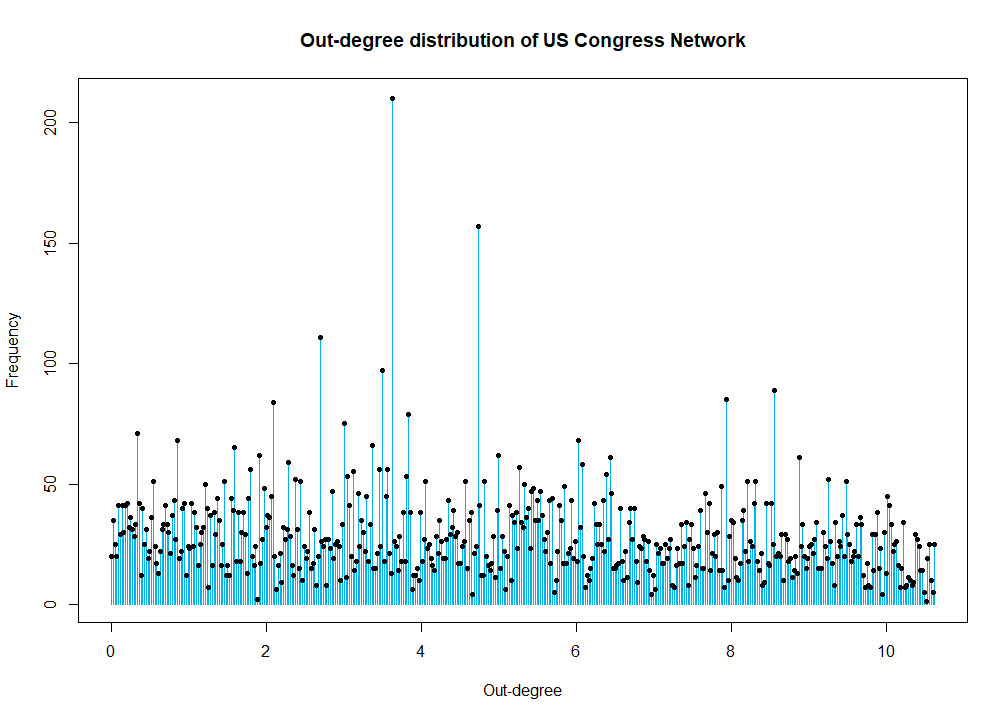

```r
par(mar=c(5,4,4,2)+0.1)
plot(seq(0, max(out_degree_weighted_dis), length.out = length(out_degree_weighted_dis)), degree(g, mode = "out"), col=color_1,
     main="Out-degree distribution of US Congress Network",
     xlab="Out-degree", ylab="Frequency", type="h", lwd=1.5)
points(seq(0, max(out_degree_weighted_dis), length.out = length(out_degree_weighted_dis)), degree(g, mode = "out"), pch=20)
```

We can see that neither are skewed. Consequently, we plot the weighted degree distribution in log scale, i.e., plot log of the weighted degrees vs log of the probabilities (relative frequencies). As before, we plot only those log-weighted-degrees and log-probabilities corresponding to weighted degrees and probabilities larger than 0, in this case, for both in and our edges.

```r
weighted_degree_dis_positive_in <- which(in_degree_weighted_dis!=0)
weighted_degree_dis_positive_in
```

```
##   [1]   1   2   3   4   5   6   7   8   9  10  11  12  13  14  15  16  17  18
##  [19]  19  20  21  22  23  24  25  26  27  28  29  30  31  32  33  34  35  36
##  [37]  37  38  39  40  41  42  43  44  45  46  47  48  49  50  51  52  53  54
##  [55]  55  57  58  59  60  61  62  63  64  65  66  67  68  69  70  71  72  73
##  [73]  74  76  77  78  80  83  84  85  86  87  88  89  90  91  92  93  97  99
##  [91] 101 102 103 104 105 106 107 109 110 111 112 116 117 118 119 124 125 128
## [109] 129 133 134 136 145 147 149 152 153 155 168 170 172 176 178 179 183 184
## [127] 185 205 210 235 240 275 279 475
```

```r
weighted_degree_dis_positive_out <- which(out_degree_weighted_dis!=0)
weighted_degree_dis_positive_out
```

```
##   [1]   1   4   7   9  10  11  12  14  15  16  18  19  20  21  22  23  24  25
##  [19]  26  27  28  29  30  31  32  33  34  35  36  37  38  39  40  41  42  43
##  [37]  44  45  46  47  48  49  50  51  52  53  54  55  56  57  58  59  60  61
##  [55]  62  63  64  65  66  67  68  69  70  71  72  73  74  75  76  77  78  79
##  [73]  80  81  82  83  84  85  86  87  88  89  90  91  92  93  94  95  96  97
##  [91]  98  99 100 101 102 103 104 105 108 109 110 111 113 115 116 117 118 119
## [109] 120 121 122 123 124 125 127 128 129 132 133 135 136 137 138 139 140 141
## [127] 144 145 146 149 150 151 156 157 159 160 162 164 165 166 168 169 172 174
## [145] 181 190 197 199 200 203 204 205 211 213 222 224 225 228 230 239 241 254
## [163] 261 265 272 304 327 350 417 438 471 475
```

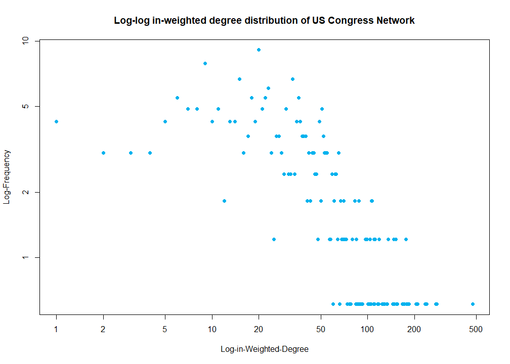

```r
plot(weighted_degree_dis_positive_in,
     in_degree_weighted_dis[weighted_degree_dis_positive_in],
     log="xy",col=color_1,main="Log-log in-weighted degree distribution of US Congress Network",
     xlab="Log-in-Weighted-Degree",ylab="Log-Frequency",pch=19,lwd=1.5)
```

We eliminate the first four observations to improve linearity.

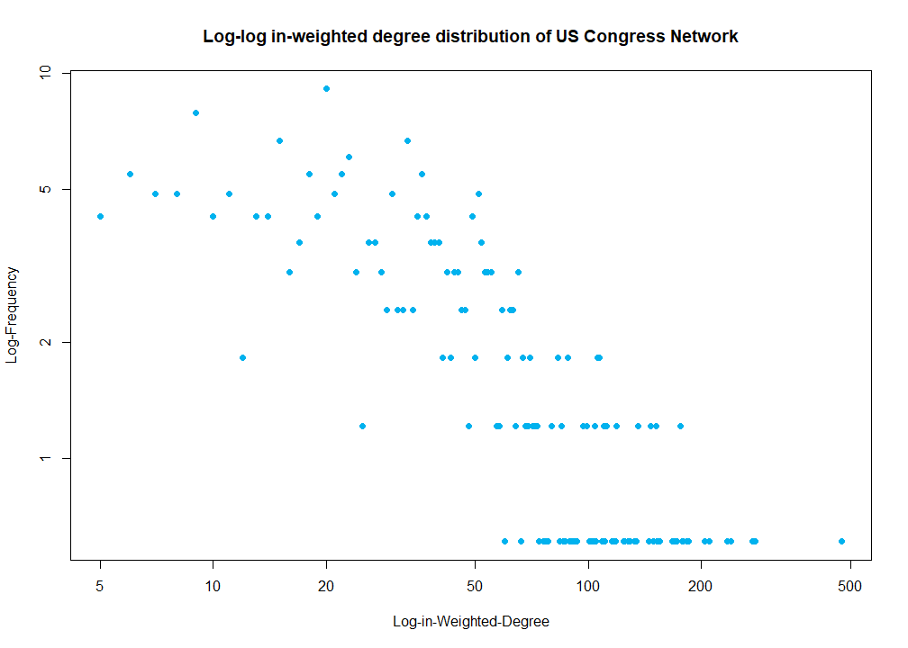

```r
plot(weighted_degree_dis_positive_in[-c(1,2,3,4)],
     in_degree_weighted_dis[weighted_degree_dis_positive_in][-c(1,2,3,4)],
     log="xy",col=color_1,main="Log-log in-weighted degree distribution of US Congress Network",
     xlab="Log-in-Weighted-Degree",ylab="Log-Frequency",pch=19,lwd=1.5)
```

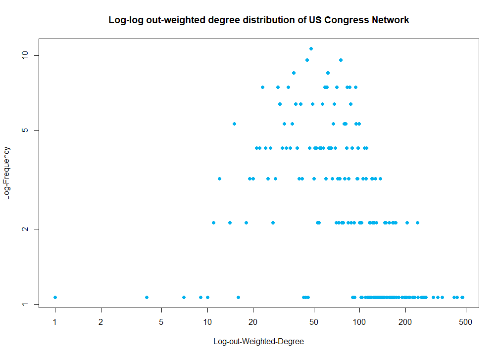

```r
plot(weighted_degree_dis_positive_out,
     out_degree_weighted_dis[weighted_degree_dis_positive_out],
     log="xy",col=color_1,main="Log-log out-weighted degree distribution of US Congress Network",
     xlab="Log-out-Weighted-Degree",ylab="Log-Frequency",pch=19,lwd=1.5)
```

We fit the linear regressions.

```r
log_weighted_deg_dist_in <- log(in_degree_weighted_dis[weighted_degree_dis_positive_in])[-c(1,2,3,4)]
log_weighted_deg_in <- log(weighted_degree_dis_positive_in)[-c(1,2,3,4)]
first_fit_w_in <- lm(log_weighted_deg_dist_in~log_weighted_deg_in)
summary(first_fit_w_in)
```

```
##
## Call:
## lm(formula = log_weighted_deg_dist_in ~ log_weighted_deg_in)
##
## Residuals:
##      Min       1Q   Median       3Q      Max
## -1.07961 -0.35620 -0.05548  0.39734  1.02402
##
## Coefficients:
##                     Estimate Std. Error t value Pr(>|t|)
## (Intercept)          3.60677    0.19818   18.20   <2e-16 ***
## log_weighted_deg_in -0.77600    0.04698  -16.52   <2e-16 ***
## ---
## Signif. codes:  0 '***' 0.001 '**' 0.01 '*' 0.05 '.' 0.1 ' ' 1
##
## Residual standard error: 0.472 on 128 degrees of freedom
## Multiple R-squared:  0.6807, Adjusted R-squared:  0.6782
## F-statistic: 272.9 on 1 and 128 DF,  p-value: < 2.2e-16
```

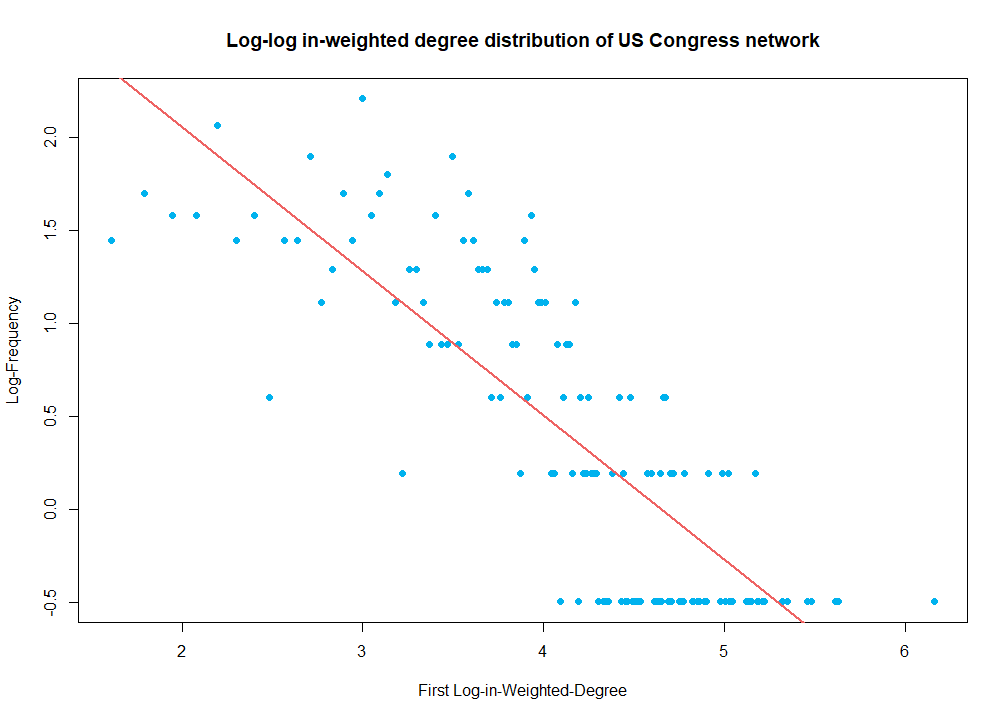

```r
plot(log_weighted_deg_in,log_weighted_deg_dist_in,
     col=color_1,main="Log-log in-weighted degree distribution of US Congress network",
     xlab="First Log-in-Weighted-Degree",ylab="Log-Frequency",pch=19)
abline(first_fit_w_in$coefficients[1],first_fit_w_in$coefficients[2],col=color_2,lwd=2)
```

```r
second_fit_in <- lm(log_weighted_deg_dist_in~log_weighted_deg_in,weights=1/first_fit_w_in$fitted.values^2)
summary(second_fit_in)
```

```
##
## Call:
## lm(formula = log_weighted_deg_dist_in ~ log_weighted_deg_in,
##     weights = 1/first_fit_w_in$fitted.values^2)
##
## Weighted Residuals:
##      Min       1Q   Median       3Q      Max
## -106.294   -0.695   -0.070    0.699   68.471
##
## Coefficients:
##                     Estimate Std. Error t value Pr(>|t|)
## (Intercept)           3.5881     4.3473   0.825    0.411
## log_weighted_deg_in  -0.7713     0.9356  -0.824    0.411
##
## Residual standard error: 13.73 on 128 degrees of freedom
## Multiple R-squared:  0.005281,   Adjusted R-squared:  -0.00249
## F-statistic: 0.6796 on 1 and 128 DF,  p-value: 0.4113
```

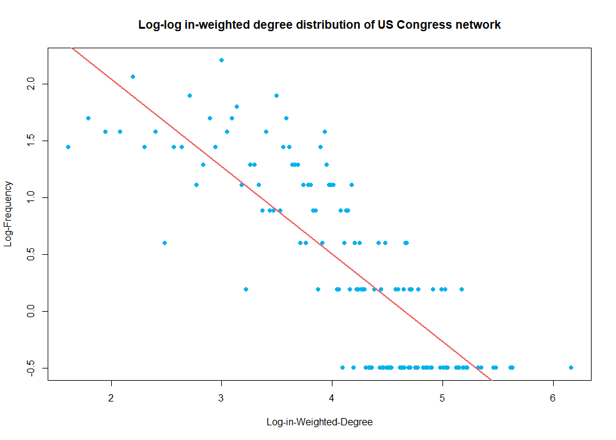

```r
plot(log_weighted_deg_in,log_weighted_deg_dist_in,
     col=color_1,main="Log-log in-weighted degree distribution of US Congress network",
     xlab="Log-in-Weighted-Degree",ylab="Log-Frequency",pch=19)
abline(second_fit_in$coefficients[1],second_fit_in$coefficients[2],col=color_2,lwd=2)
```

```r
log_weighted_deg_dist_out <- log(out_degree_weighted_dis[weighted_degree_dis_positive_out])
log_weighted_deg_out <- log(weighted_degree_dis_positive_out)
first_fit_w_out <- lm(log_weighted_deg_dist_out~log_weighted_deg_out)
summary(first_fit_w_out)
```

```
##
## Call:
## lm(formula = log_weighted_deg_dist_out ~ log_weighted_deg_out)
##
## Residuals:
##      Min       1Q   Median       3Q      Max
## -2.11503 -0.53047 -0.01195  0.47997  1.41451
##
## Coefficients:
##                      Estimate Std. Error t value Pr(>|t|)
## (Intercept)           2.17535    0.24421   8.908 7.75e-16 ***
## log_weighted_deg_out -0.30859    0.05442  -5.671 5.99e-08 ***
## ---
## Signif. codes:  0 '***' 0.001 '**' 0.01 '*' 0.05 '.' 0.1 ' ' 1
##
## Residual standard error: 0.6554 on 170 degrees of freedom
## Multiple R-squared:  0.1591, Adjusted R-squared:  0.1541
## F-statistic: 32.16 on 1 and 170 DF,  p-value: 5.993e-08
```

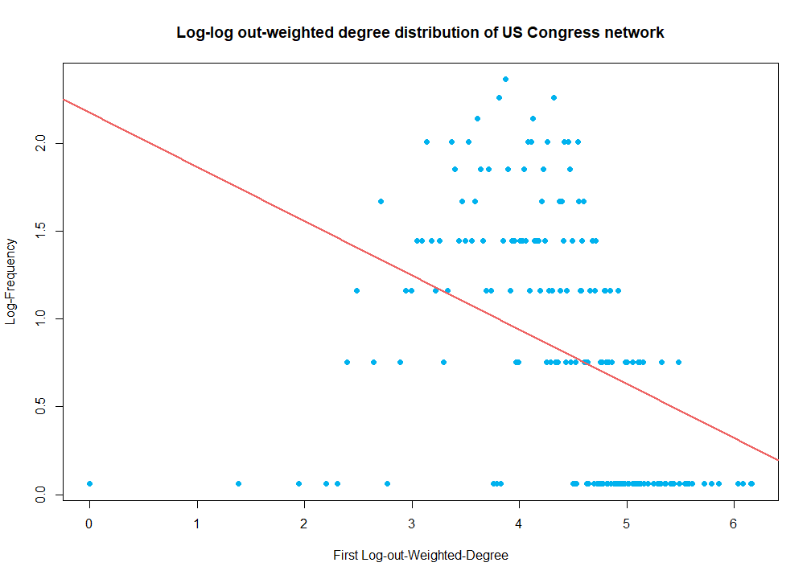

```r
plot(log_weighted_deg_out,log_weighted_deg_dist_out,
     col=color_1,main="Log-log out-weighted degree distribution of US Congress network",
     xlab="First Log-out-Weighted-Degree",ylab="Log-Frequency",pch=19)
abline(first_fit_w_out$coefficients[1],first_fit_w_out$coefficients[2],col=color_2,lwd=2)
```

```r
second_fit_w_out <- lm(log_weighted_deg_dist_out~log_weighted_deg_out,weights=1/first_fit_w_out$fitted.values^2)
summary(second_fit_w_out)
```

```
##
## Call:
## lm(formula = log_weighted_deg_dist_out ~ log_weighted_deg_out,
##     weights = 1/first_fit_w_out$fitted.values^2)
##
## Weighted Residuals:
##      Min       1Q   Median       3Q      Max
## -1.44860 -0.65020 -0.03875  0.53711  1.63138
##
## Coefficients:
##                      Estimate Std. Error t value Pr(>|t|)
## (Intercept)           3.21152    0.24225   13.26   <2e-16 ***
## log_weighted_deg_out -0.53950    0.04807  -11.22   <2e-16 ***
## ---
## Signif. codes:  0 '***' 0.001 '**' 0.01 '*' 0.05 '.' 0.1 ' ' 1
##
## Residual standard error: 0.7174 on 170 degrees of freedom
## Multiple R-squared:  0.4256, Adjusted R-squared:  0.4222
## F-statistic: 125.9 on 1 and 170 DF,  p-value: < 2.2e-16
```

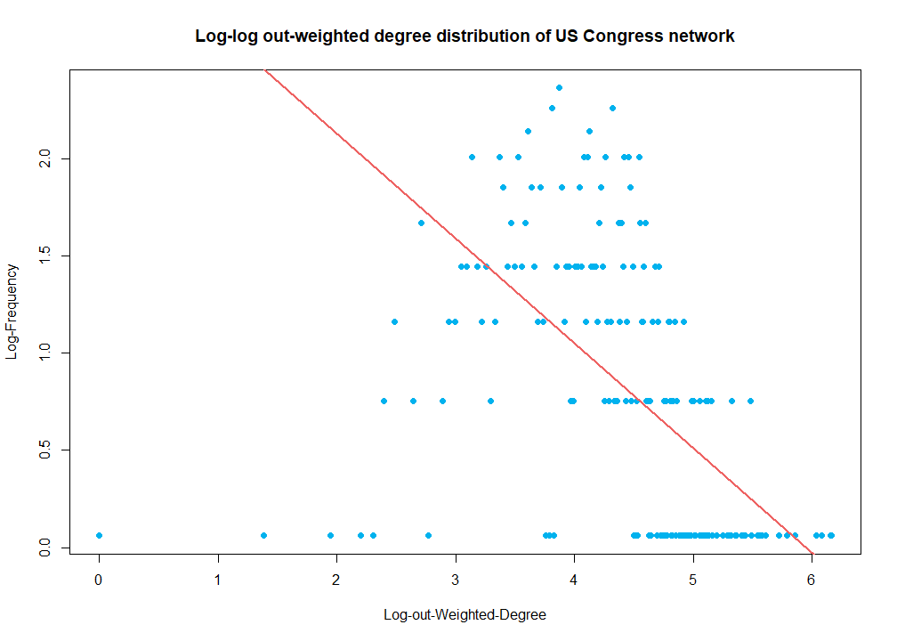

```r
plot(log_weighted_deg_out,log_weighted_deg_dist_out,
     col=color_1,main="Log-log out-weighted degree distribution of US Congress network",
     xlab="Log-out-Weighted-Degree",ylab="Log-Frequency",pch=19)
abline(second_fit_w_out$coefficients[1], second_fit_w_out$coefficients[2],col=color_2,lwd=2)
```

### 3.5.3 Conclusions

The in-degree distribution of our graph provides valuable insights into its structure, especially when considering weighted edges. Our weighted in-degree distribution captures the importance or significance of nodes based on the sum of weights of incoming edges, providing a nuanced understanding of node centrality in the network.

# 4 Assignment 4

## 4.1 Vertex centrality measures

There exist plenty of different measures of vertex centrality in networks. We will study our netowrk through some of the simplest or most famous ones: vertex degree, closeness, betweenness, eigenvector and PageRank.

### 4.1.1 Vertex degree

We will start by applying the simplest centrality measure: vertex degree. Since we are dealing with a weighted directed network, all possible computations of the vertex degree will be taken into account.

We can start by computing the total vertex degree:

```r
total_deg = sort.int(degree(g), decreasing=T, index.return=T)
total_deg$x[1:5]
```

```
##       Mike Gallagher          Steve Cohen            Mike Bost
##                  284                  261                  190
##           Jason Crow Maria Elvira Salazar
##                  187                  182
```

According to this measure, Mike Gallagher is the most central vertex, followed by Steve Cohen and Mike Bost. Centrality in this case does not necessarily represent the most influential nor influenced individuals, but rather those that might influence and/or be influenced by the most people. To get a better idea of the extent of the influence the weighted vertex degree should be calculated:

```r
total_weighted = sort(strength(g), decreasing=T, index.return=T)
total_weighted$x[1:5]
```

```
##       Mike Gallagher             Tom Rice Maria Elvira Salazar
##             2.475500             1.395383             1.348551
##            Mike Bost      Morgan Griffith
##             1.226641             1.195723
```

We obtain a similar scenario, in which Mike Gallagher is the vertex with more outgoing/ingoing influence and Maria Elvira Salazar also appears in the podium, although some other new Congresspeople appear when taking into account the weights. These new people are influenced or influence less people but in a stronger manner.

To really be able to tell whether these people are influencers or followers, or even a mix of both, the in- and out- degrees need to be calculated. We can start with the in-degrees:

```r
in_deg = sort.int(degree(g, mode="in"), decreasing=T, index.return=T)
in_deg$x[1:5]
```

```
##       Mike Gallagher Maria Elvira Salazar      Martin Heinrich
##                  127                  121                  120
##       Bernie Sanders          Thom Tillis
##                  109                  108
```

Mike Gallagher and Maria Elvira Salazar appear once again, with the latter being even higher than before. Another well-known name that appears in the top 5 is that of Bernie Sanders. These central vertices (in terms of their in-degree) represent people that are influenced by a lot of different politicians in the US Congress. To make a better judgement, however, the weights have to be included in the computation:

```r
in_weighted = sort(strength(g, mode="in"), decreasing=T, index.return=T)
in_weighted$x[1:5]
```

```
##       Mike Gallagher      Morgan Griffith        Tony Cárdenas
##            1.6482815            0.9654453            0.9518529
## Maria Elvira Salazar      Lizzie Fletcher
##            0.8302263            0.8141848
```

Mike Gallagher stays at the top as the most influenced individual in US Congress. Some new names appear, only one of which (Morgan Griffith) appears at the top of the total weighted degrees. Bernie Sanders disappears from the top 5 (now being 9th), which indicates that he is influenced by a lot of people but not very strongly.

This process can be repeated for the out-degree to be able to discern the biggest influencers:

```r
out_deg = sort.int(degree(g, mode="out"), decreasing=T, index.return=T)
out_deg$x[1:5]
```

```
##    Steve Cohen Mike Gallagher      Mike Bost  Yvette Clarke       Tom Rice
##            210            157            111             97             89
```

Mike Gallagher also appears as a person that influences many others, although just behind the first spot taken by Steve Cohen, who did not seem to be too influenced earlier.

```r
out_weighted = sort(strength(g, mode="out"), decreasing=T, index.return=T)
out_weighted$x[1:5]
```

```
##    Steve Cohen       Tom Rice      Mike Bost Mike Gallagher  Diana DeGette
##      0.9436393      0.9351145      0.8694158      0.8272189      0.6952381
```

### 4.1.2 Closeness centrality

The next centrality measure studied is that of closeness centrality, which deals with the distances of vertices to one another. It is important to take into account that, as we saw in previous weeks, ours is a directed network with seven (strong) components. Since 6 out of the 7 components contain only one vertex each, the closeness centrality will be calculated only for the largest component.

```r
components_g = components(g, mode="strong")
g_large = induced_subgraph(g,
                           components_g$membership==which.max(components_g$csize))
closeness_g = sort(closeness(g_large, normalized=TRUE, mode="out", weights=rep(1,ecount(g_large))),
                             decreasing=TRUE, index.return=TRUE)
closeness_g$x[1:5]
```

```
##    Steve Cohen Mike Gallagher  Yvette Clarke      Mike Bost     Jason Crow
##      0.6393443      0.5770654      0.5366972      0.5252525      0.5205784
```

Once again, we see some familiar names such as Steve Cohen, Mike Gallagher, or Mike Bost. The high closeness centrality of these Congresspeople indicates that, apart from influencing many people, they are the ones whose influence takes less intermediaries to reach those who are not directly influenced by them. As usual, however, weights should be taken into account before making any claim on the extent of influences of these people.

In order to include weights in the computation, it is important realize that in this network bigger weights indicate higher influence, and so a closer relationship between two Congresspeople. Therefore, when computing distances between vertices, they must be inversely proportional to the weights.

```r
weighted_closeness = sort.int(closeness(g_large, normalized=T, mode="out",
                                        weights=1/E(g_large)$weight),
                             decreasing=TRUE, index.return=TRUE)
weighted_closeness$x[1:10]
```

```
##        Tim Ryan    David Rouzer   Diana DeGette      Ann Wagner     John Curtis
##     0.004008837     0.003874517     0.003837360     0.003831530     0.003782422
## William Timmons       Mike Bost    Ralph Norman    Bill Hagerty        Tom Rice
##     0.003765047     0.003726212     0.003712338     0.003711619     0.003696282
```

For the first five people, we obtain vastly different results to the ones seen up until this point, although when considering the first ten people instead, Mike Bost and Tom Rice appear once again. As opposed to standard closeness, weighted closeness is influenced by both the amount of intermediaries and how strong those intermediaries both influence and are influenced, that is, the individuals ranking at the top of weighted closeness are the ones that, although perhaps seeming unimportant at first, are able to truly influence other people the fastest, even if not directly due to their low vertex degree.

### 4.1.3 Betweenness centrality

Next, betweenness centrality can be considered. This centrality measure assigns higher centrality to those vertices which are necessary to cross through in order to reach others, that is, intermediaries through which the influence must go in order to further spread.

```r
betweenness_g = sort(betweenness(g, normalized=T, directed=T, weights=rep(1,ecount(g))),
                     decreasing=T, index.return=T)
betweenness_g$x[1:5]
```

```
## Mike Gallagher    Steve Cohen     Jason Crow      Mike Bost     John Thune
##     0.07304130     0.04141240     0.03068303     0.02717765     0.01775275
```

Once again, the same three names are repeated, together with two new ones.

Taking into account the weights of the network just as we did before:

```r
weighted_betweenness = sort(betweenness(g, normalized=T, directed=T, weights=1/E(g)$weight),
                     decreasing=T, index.return=T)
weighted_betweenness$x[1:5]
```

```
##       Mike Gallagher Maria Elvira Salazar            Mike Bost
##           0.18962364           0.07381290           0.05912302
##             Tom Rice        Diana DeGette
##           0.04867263           0.04747058
```

We see some already seen names, among which Mike Gallagher is far ahead of all others in terms of centrality. These individuals are the ones that, when taking influence into account, serve as gateways from whom one’s influence can reach others the fastest.

### 4.1.4 Eigenvector centrality

The next centrality measure studied is that of eigenvector centrality, which is related to the “status” of a vertex within a network.

First, we consider standard eigenvector centrality:

```r
eigen_g = sort(eigen_centrality(g, directed=T, scale=F, weights=rep(1,ecount(g)))$vector,
               decreasing=T, index.return=T)
eigen_g$x[1:5]
```

```
##       Mike Gallagher      Martin Heinrich Maria Elvira Salazar
##            0.1772418            0.1720535            0.1628683
##      Morgan Griffith          Thom Tillis
##            0.1598957            0.1526360
```

Once again, Mike Gallagher comes out on top, which indicates that he is an influencer within the US Congress network who at the same time influences a lot of other influencers. We can repeat the computation taking the weights of the network into account:

```r
weighted_eigen = sort(eigen_centrality(g, directed=T, scale=F, weights=E(g)$weight)$vector,
               decreasing=T, index.return=T)
weighted_eigen$x[1:5]
```

```
##  Mike Gallagher   Tony Cárdenas Morgan Griffith Debbie Stabenow   Chuck Schumer
##       0.3765942       0.2676286       0.2548532       0.2143012       0.1923158
```

When taking into account the weights, the ranking changes all except the first position, which is still held by Mike Gallagher. This but confirms his status as the individual who influences the most influencers.

### 4.1.5 PageRank centrality

Finally, the last vertex centrality measure computed will be PageRank centrality, which is similar to eigenvector centrality.

```r
pagerank_g = sort(page_rank(g, weights=rep(1,ecount(g)))$vector,
            decreasing=T, index.return=T)
pagerank_g$x[1:5]
```

```
##       Mike Gallagher Maria Elvira Salazar      Martin Heinrich
##          0.009326025          0.009241611          0.008851418
##          Thom Tillis    John Hickenlooper
##          0.008454023          0.008408088
```

```r
weighted_pagerank = sort(page_rank(g, weights=E(g)$weight)$vector,
            decreasing=T, index.return=T)
weighted_pagerank$x[1:5]
```

```
##  Mike Gallagher Lizzie Fletcher   Tony Cárdenas Morgan Griffith     Sean Casten
##      0.01672290      0.01282085      0.01105668      0.01068356      0.01056036
```

Once again, we see Mike Gallagher come out on top of both standard and weighted PageRank centrality rankings, confirming his status of big influencer within the US Congress network.

## 4.2 Edges centrality measures

In this section, we are going to focus on computing edge centrality. Unfortunately, most of the centrality measures for vertices cannot be easily extended to measure the centrality of edges. Therefore, we focus on the betweenness centrality that has a straightforward extension to the case of edges. For that, we use the function called `edge_betweenness` of the `igraph` library to obtain the betweenness centrality of the edges of our USA Congresspeople graph.

The betweenness centrality is a widely used measure for identifying central edges in a network. It quantifies the importance of an edge based on how often it lies on the shortest paths between pairs of nodes in the network. Edges with high betweenness centrality play a crucial role in maintaining efficient communication and connectivity within the network.

We first compute it without weights, but taking into account its directed nature. The betweenness centrality essentially measures how often an edge acts as a bridge or intermediary between different nodes. Edges with high betweenness centrality are crucial for maintaining efficient communication and connectivity within the network and the ones with the lowest are disposable.

In directed networks, betweenness centrality for an edge considers the directed nature of relationships between nodes. This means that the edge’s directionality influences its contribution to the network’s overall betweenness centrality.

```r
edge_centrality <- sort.int(edge_betweenness(g, weights=rep(1,ecount(g)), directed = TRUE),
                        decreasing=TRUE,index.return=TRUE)
edge_centrality$x[1:30]
```

```
##  [1] 731.1007 600.2200 554.4835 549.6281 514.9555 482.7486 478.4696 474.2680
##  [9] 468.2680 435.7622 416.9999 412.5112 396.0814 394.5249 369.9497 366.3131
## [17] 364.0304 359.7919 356.9373 350.1125 344.7461 344.0888 342.4616 339.1356
## [25] 334.7273 325.7247 323.2850 322.6865 318.8513 315.6721
```

We have computed the values of the betweenness centrality measure for all of our 13289 edges. We wanna see the ones with the highest values, in other words, the most influential edges in maintaining efficient connectivity in our graph.

```r
E(g)[edge_centrality$ix][1:10]
```

```
## + 10/13289 edges from b93968b (vertex names):
##  [1] Jason Crow      ->Mike Gallagher
##  [2] David Carter    ->John Sarbanes
##  [3] Chuck Schumer   ->Mike Bost
##  [4] Tony Cárdenas   ->Vicky Hartzler
##  [5] Mike Gallagher  ->Mike Braun
##  [6] Alex Padilla    ->Marjorie Taylor Greene
##  [7] Vicky Hartzler  ->Rick Larsen
##  [8] John Sarbanes   ->Frederica Wilson
##  [9] Frederica Wilson->Frank Lucas
## [10] Mike Gallagher  ->Chris Coons
```

These are the most crucial connections if we only take into account which congresspeople interact. As we saw in the vertices centrality measures Mike Gallagher is a very central player in the graph. Its influenced and influences strongly other people, so it does not come as a surprise when we see it in our most crucial edges as both the begin and the end of edges.

High-betweenness edges are essential for the connectivity of the graph. If these critical edges were to be eliminated from the network, it’s highly likely that the paths between pairs of vertices would be severely impacted.

If we were to remove these crucial edges, it could disrupt the efficient communication and connectivity within the network. This disruption may lead to an increase in the distance between pairs of vertices, potentially making it more challenging for influence to flow between different parts of the network. Moreover, the removal of these critical edges could result in the network becoming fragmented, meaning that certain pairs of vertices may no longer have a path connecting them.

We now compute this measure with weights.

```r
edge_cent_weight <- sort.int(edge_betweenness(g, weights = 1/E(g)$weight, directed = TRUE),
                             decreasing = TRUE, index.return = TRUE)
edge_cent_weight$x[1:30]
```

```
##  [1] 6452.0 5159.0 4502.0 4498.0 3865.0 3841.0 3819.0 3720.0 3705.0 3622.0
## [11] 3530.0 3527.0 2762.0 2746.5 2659.0 2603.0 2603.0 2499.5 2489.0 2458.5
## [21] 2391.0 2366.0 2318.0 2313.5 2304.0 2303.0 2242.0 2179.0 2172.0 2125.5
```

The difference in the output between the two code chunks reflects the impact of considering edge weights on the calculation of edge betweenness centrality.

When not taking onto account the weights, the resulting edge betweenness centrality scores are generally lower. This is because each edge is treated equally in terms of its influence on the shortest paths between pairs of nodes. Consequently, the computed centrality scores tend to be lower.

On the other hand, when taking into account the weights of our graph, the resulting edge betweenness centrality scores are significantly higher. This is because the edge weights provide additional information about the importance of connections between the congresspeople. As a result, edges with higher weights contribute more to the calculation of betweenness centrality, leading to higher centrality scores.

Since the values are different, it is adequate to think that the congresspeople connected are different too.

```r
E(g)[edge_cent_weight$ix][1:10]
```

```
## + 10/13289 edges from b93968b (vertex names):
##  [1] Gwen Moore          ->Ann Wagner
##  [2] Maria Elvira Salazar->Diana DeGette
##  [3] Sheila Jackson Lee  ->Mike Gallagher
##  [4] Mike Gallagher      ->Nicole Malliotakis
##  [5] Nicole Malliotakis  ->Tom Emmer
##  [6] Ben Cline           ->Susie Lee
##  [7] Tom Emmer           ->Randy Feenstra
##  [8] John Thune          ->Sara Jacobs
##  [9] Sean Casten         ->Ben Cline
## [10] Mike Gallagher      ->Brad Sherman
```

These connections are the most crucial when we consider, not only the existing interactions, but also the repetition of each one. These are in fact different edges from before. When taking into account the weights, the crucial edges for graph connectivity are different ones.

If we take a closer look at the congressperson Mike Gallagher, he has crucial edges in both settings. In the weightless graph, Mike Gallagher -> Mike Braun and Mike Gallagher-> Chris Coon; while in the weighted one, Mike Gallagher -> Nicole Malliotakis. We have seen that Mike Gallagher is crucial in the connectivity of both of our graphs, weighted and unweighted.

## 4.3 Local density

### 4.3.1 Cliques

Cliques are fundamental concepts in graph theory that represent fully connected subgraphs within a larger network. A clique is a subset of vertices in a graph where every pair of vertices is directly connected by an edge. In other words, in a clique, every vertex is adjacent to every other vertex within the subset.

Cliques are valuable in network analysis for various reasons since they provide insights into the structure and organization of networks by revealing cohesive subgroups or communities of nodes. Moreover, they can be used for tasks such as community detection, network visualization, and understanding social or communication patterns within networks. Furthermore, analyzing cliques can help identify influential nodes or groups of nodes that have strong connections with each other, indicating potential hubs of activity or influence within the network.

In this section, we aim to compute the set of cliques for our Congress network. However, since the calculation of cliques is typically performed on undirected networks, we need to create an undirected version of our graph first.

To achieve this, we’ll make a copy of our original graph but convert it into an undirected graph. This process ensures that each directed edge in our original graph becomes an undirected edge in the new graph, allowing us to analyze cliques effectively.

By performing these steps, we’ll be able to analyze the cliques within our Congress network effectively, gaining insights into cohesive subgroups or communities within the network of Congressional interactions.

```r
## Convert the directed graph to an undirected one
g_un <- as.undirected(g, mode = "collapse")
```

```r
## Compute the set of cliques for the undirected graph
cliques <- cliques(g_un)
length(cliques)
```

```
## [1] 1053456
```

We can see that we have an enormous amount of cliques within our undirected graph. Let’s see how many we have of each size.

```r
table(sapply(cliques,length))
```

```
##
##      1      2      3      4      5      6      7      8      9     10     11
##    475  10222  52333 136659 228290 258764 203166 110531  41064  10172   1622
##     12     13
##    152      6
```

We have, of course, $475$ cliques of size $1$, which correspond to our number of vertices. Moving on, we observe $10222$ cliques of size $2$. These cliques represent pairs of congresspeople who have established direct connections with each other. It’s noteworthy that the number of cliques of size $2$ is not equal to the number of edges in our directed graph, which was $13289$. This discrepancy arises because, in the process of making our graph undirected, some edges were collapsed. Specifically, instances where pairs of congresspeople had reciprocal edges (one edge in each direction) were merged into a single undirected edge.

Moreover, we can see that we have $52333$ triangles (cliques of size $3$), $136659$ cliques of size $4$ and so on. Now, we are interested to see which vertices correspond to the $6$ cliques of size $13$ that we have.

```r
largest_cliques(g_un)
```

```
## [[1]]
## + 13/475 vertices, named, from 51957a9:
##  [1] Debbie Stabenow  Tony Cárdenas    Kat Cammack      Chuck Schumer
##  [5] Dan Kildee       John Larson      Josh Gottheimer  David Schweikert
##  [9] Al Green         Martin Heinrich  Tina Smith       Michael Guest
## [13] Morgan Griffith
##
## [[2]]
## + 13/475 vertices, named, from 51957a9:
##  [1] Debbie Stabenow  Tony Cárdenas    Kat Cammack      Chuck Schumer
##  [5] Dan Kildee       John Larson      Josh Gottheimer  David Schweikert
##  [9] Al Green         Martin Heinrich  Tina Smith       Michael Guest
## [13] Brett Guthrie
##
## [[3]]
## + 13/475 vertices, named, from 51957a9:
##  [1] Debbie Stabenow  Tony Cárdenas    Kat Cammack      Chuck Schumer
##  [5] Dan Kildee       John Larson      Josh Gottheimer  David Schweikert
##  [9] Al Green         Martin Heinrich  Tina Smith       Glenn Grothman
## [13] Morgan Griffith
##
## [[4]]
## + 13/475 vertices, named, from 51957a9:
##  [1] Debbie Stabenow  Tony Cárdenas    Kat Cammack      Chuck Schumer
##  [5] Dan Kildee       John Larson      Josh Gottheimer  David Schweikert
##  [9] Al Green         Martin Heinrich  Tina Smith       Glenn Grothman
## [13] Brett Guthrie
##
## [[5]]
## + 13/475 vertices, named, from 51957a9:
##  [1] Debbie Stabenow      Tony Cárdenas        Mike Gallagher
##  [4] Chuck Schumer        Maria Elvira Salazar Morgan Griffith
##  [7] Martin Heinrich      Tom Rice             Anna Eshoo
## [10] Tina Smith           John Larson          Chris Jacobs
## [13] Raul Grijalva
##
## [[6]]
## + 13/475 vertices, named, from 51957a9:
##  [1] Debbie Stabenow      Tony Cárdenas        Mike Gallagher
##  [4] Chuck Schumer        Maria Elvira Salazar Morgan Griffith
##  [7] Martin Heinrich      Tom Rice             Anna Eshoo
## [10] Garret Graves        John Larson          Chris Jacobs
## [13] Raul Grijalva
```

We can see that congressman Debbie Stabenow appears in several cliques, including those with Tony Cárdenas, Kat Cammack, Chuck Schumer, and others. These cliques indicate cohesive subgroups where members frequently interact or collaborate on legislative matters. Moreover, we can see an overlap in the cliques, congresswoman Kat Cammack is a member of cliques that also include Chuck Schumer, Debbie Stabenow, and Tony Cárdenas. This overlap suggests that Kat Cammack serves as a bridge between different cohesive subgroups within the network, facilitating communication and collaboration between them.

Furthermore, we can see a variety of congresspeople involves. For example, congressman John Larson, representing Connecticut’s 1st congressional district, appears in cliques alongside representatives from diverse regions and political parties, such as Kat Cammack from Florida, Debbie Stabenow from Michigan, and Chuck Schumer from New York. This diversity reflects the broad range of interactions and collaborations within the Congress network.

In addition, we observe some potential for bipartisanship, since senator Chuck Schumer, a Democrat from New York, is present in cliques that include both Democratic and Republican members, such as Debbie Stabenow, a Democrat, and Kat Cammack, a Republican. This indicates opportunities for bipartisanship and collaboration across party lines on legislative initiatives.

Finally, we can identify some key figures, because senator Chuck Schumer appears in multiple large cliques, including those with Debbie Stabenow, Kat Cammack, and others. His presence in these cliques suggests that he plays a central role in facilitating connections and interactions within the network, potentially influencing the flow of information and collaboration among members.

We have taken a look at the cliques of the largest order, but what about the other cliques? Are they maximal or are they just subgraphs from the $13$ largest cliques? To investigate this we are going to compute the maximal cliques of our graph.

```r
max_cliques <- max_cliques(g)
head(max_cliques, n = 30)
```

```
## [[1]]
## + 2/475 vertices, named, from b93968b:
## [1] Frederica Wilson John Sarbanes
##
## [[2]]
## + 2/475 vertices, named, from b93968b:
## [1] Frederica Wilson Frank Lucas
##
## [[3]]
## + 2/475 vertices, named, from b93968b:
## [1] John Yarmuth Dina Titus
##
## [[4]]
## + 2/475 vertices, named, from b93968b:
## [1] John Yarmuth  Chris Stewart
##
## [[5]]
## + 2/475 vertices, named, from b93968b:
## [1] John Yarmuth Dan Bishop
##
## [[6]]
## + 3/475 vertices, named, from b93968b:
## [1] John Yarmuth         Don Bacon            Sean Patrick Maloney
##
## [[7]]
## + 3/475 vertices, named, from b93968b:
## [1] Joe Wilson        Diana Harshbarger Carlos Giménez
##
## [[8]]
## + 2/475 vertices, named, from b93968b:
## [1] Joe Wilson Rick Allen
##
## [[9]]
## + 3/475 vertices, named, from b93968b:
## [1] Joe Wilson   Marco Rubio  Bill Johnson
##
## [[10]]
## + 2/475 vertices, named, from b93968b:
## [1] Scott Franklin  Bruce Westerman
##
```

[output cut: 64 more lines]

```
## [[27]]
## + 2/475 vertices, named, from b93968b:
## [1] Steve Womack Marc Veasey
##
## [[28]]
## + 2/475 vertices, named, from b93968b:
## [1] Steve Womack    Patrick McHenry
##
## [[29]]
## + 3/475 vertices, named, from b93968b:
## [1] Steve Womack Nancy Mace   Anna Eshoo
##
## [[30]]
## + 2/475 vertices, named, from b93968b:
## [1] Steve Womack   Carlos Giménez
```

We can see that we have many small cliques, several cliques consist of only two congresspeople, such as Frederica Wilson and John Sarbanes, or Frederica Wilson and Frank Lucas. These smaller cliques may represent pairs of congresspeople who share common interests or frequently collaborate on specific issues. Moreover, there is some overlap between cliques, where certain congresspeople appear in multiple cliques. For example, John Yarmuth appears in cliques with different congresspeople, including Dina Titus, Chris Stewart, and Dan Bishop. This overlap suggests that John Yarmuth plays a bridging role between different cohesive subgroups within the network.

Moreover, the variety of the background of the present people in a graph remains presenting a diverse range of backgrounds, political affiliations, and regions. For instance, Joe Wilson interacts with Diana Harshbarger and Carlos Giménez in one clique and with Marco Rubio and Bill Johnson in another. This diversity reflects the broad spectrum of interactions and collaborations within the Congress network. Once again, we have members of different political parties (Democrat and Republican) collaborating. For example, Steve Womack interacts with both Marc Veasey and Patrick McHenry, suggesting opportunities for cooperation on legislative matters despite differing party affiliations.

A key figure that we can identify from these cliques is, for example, Donald Norcross, who is involved in several cliques with different combinations of congresspeople, indicating his central role in the network.

However, we have not seen what happened with those cliques of a higher order. For that we compute the following table:

```r
table(sapply(max_cliques,length))
```

```
##
##    2    3    4    5    6    7    8    9   10   11   12   13
##   94 1041 2018 2935 3800 4142 3429 2643 1403  389   79    6
```

We can see that none of the cliques of order $1$ are maximal cliques. Moreover, only $94$ out of the $10222$ cliques of degree $2$ are maximal cliques. Furthermore, out of the $52333$ cliques of order $3$, $1041$ are maximal. In general, the number of maximal cliques out of the total number of cliques at one degree is much smaller, except with degree $13$, where all are maximal cliques.

### 4.3.2 Graph coreness

Graph coreness is a measure used in graph theory to quantify the structural centrality of nodes within a graph. It indicates how “deep” a node is within the core structure of the graph.

The coreness of a node is determined by recursively peeling away its neighbors and itself until it can no longer be removed without reducing the degree of its neighbors below a certain threshold. The highest coreness value in the graph is the coreness of the most central node.

Nodes with higher coreness values are considered more central to the overall structure of the graph, as they have more connections to other nodes that are also well-connected. Coreness is often used in network analysis to identify important nodes or to understand the robustness and resilience of a network.

```r
cores <- sort(coreness(g), decreasing = TRUE)
cores[1:10]
```

```
##           Bill Cassidy            Chris Coons Catherine Cortez Masto
##                     35                     35                     35
##             Tom Cotton           Kevin Cramer            Josh Hawley
##                     35                     35                     35
##        Martin Heinrich      John Hickenlooper           Mazie Hirono
##                     35                     35                     35
##            John Hoeven
##                     35
```

```r
table(cores)
```

```
## cores
##   2   5   7   8   9  10  11  12  13  14  15  16  17  18  19  20  21  22  23  24
##   1   2   1   1   1   2   4   2   4   2   2   3   2   5   2   2   5  11  10   9
##  25  26  27  28  29  30  31  32  33  34  35
##   6  13   8   8  11  17  20  31  17  98 175
```

We can see that, the top $10$ nodes identified, including “Bill Cassidy,” “Chris Coons,” “Catherine Cortez Masto,” “Tom Cotton,” “Kevin Cramer,” “Josh Hawley,” “Martin Heinrich,” “John Hickenlooper,” “Mazie Hirono,” and “John Hoeven,” all possess the maximum coreness value of $35$. This collective maximum suggests a highly central position within the network, implying strong connections to other nodes.

Furthermore, the concentration of vertices with the highest coreness value of $35$ stands out prominently, encompassing $175$ out of $475$ vertices. This concentration underscores the existence of a core group of highly connected nodes, implying significant roles in information dissemination or influence propagation within the network.

We can take a look at the vertices (congresspeople), which have the highest coreness value.

```r
which(cores==max(cores))
```

```
##           Bill Cassidy            Chris Coons Catherine Cortez Masto
##                      1                      2                      3
##             Tom Cotton           Kevin Cramer            Josh Hawley
##                      4                      5                      6
##        Martin Heinrich      John Hickenlooper           Mazie Hirono
##                      7                      8                      9
##            John Hoeven         Cynthia Lummis            Joe Manchin
##                     10                     11                     12
##              Ed Markey           Bob Menendez            Marco Rubio
##                     13                     14                     15
##         Bernie Sanders          Chuck Schumer             Rick Scott
##                     16                     17                     18
##              Tim Scott             Tina Smith        Debbie Stabenow
##                     19                     20                     21
##             Jon Tester             John Thune            Thom Tillis
##                     22                     23                     24
##       Tommy Tuberville            Mark Warner             Alma Adams
##                     25                     26                     27
##        Robert Aderholt           Pete Aguilar       Jake Auchincloss
##                     28                     29                     30
##             Cindy Axne            Brian Babin              Don Bacon
##                     31                     32                     33
##              Jim Baird           Joyce Beatty         Sanford Bishop
##                     34                     35                     36
##        Brenda Lawrence              Mike Bost          Shontel Brown
##                     37                     38                     39
##           Tim Burchett        Michael Burgess           Cheri Bustos
##                     40                     41                     42
##            Kat Cammack         Salud Carbajal          Tony Cárdenas
##                     43                     44                     45
##           David Carter            Troy Carter                Ed Case
##                     46                     47                     48
##            Sean Casten         Joaquin Castro       Madison Cawthorn
##                     49                     50                     51
##             Karen Bass               Judy Chu          Yvette Clarke
##                     52                     53                     54
##              Ben Cline          Michael Cloud           Andrew Clyde
##                     55                     56                     57
##            Steve Cohen               Tom Cole            James Comer
##                     58                     59                     60
```

[output cut: 63 more lines]

```
##                    154                    155                    156
##       David Schweikert          Pete Sessions           Mike Simpson
##                    157                    158                    159
##            Albio Sires           Adrian Smith            Jason Smith
##                    160                    161                    162
##          Lloyd Smucker     Abigail Spanberger          Jackie Speier
##                    163                    164                    165
##      Melanie Stansbury           Greg Stanton         Elise Stefanik
##                    166                    167                    168
##            Bryan Steil          Haley Stevens          Chris Stewart
##                    169                    170                    171
##            Tom Tiffany        William Timmons            David Trone
##                    172                    173                    174
##            Mike Turner
##                    175
```

We delve further into the analysis of the coreness values of our network by plotting them in a histogram to have a visual representation and see if we can draw new insights.

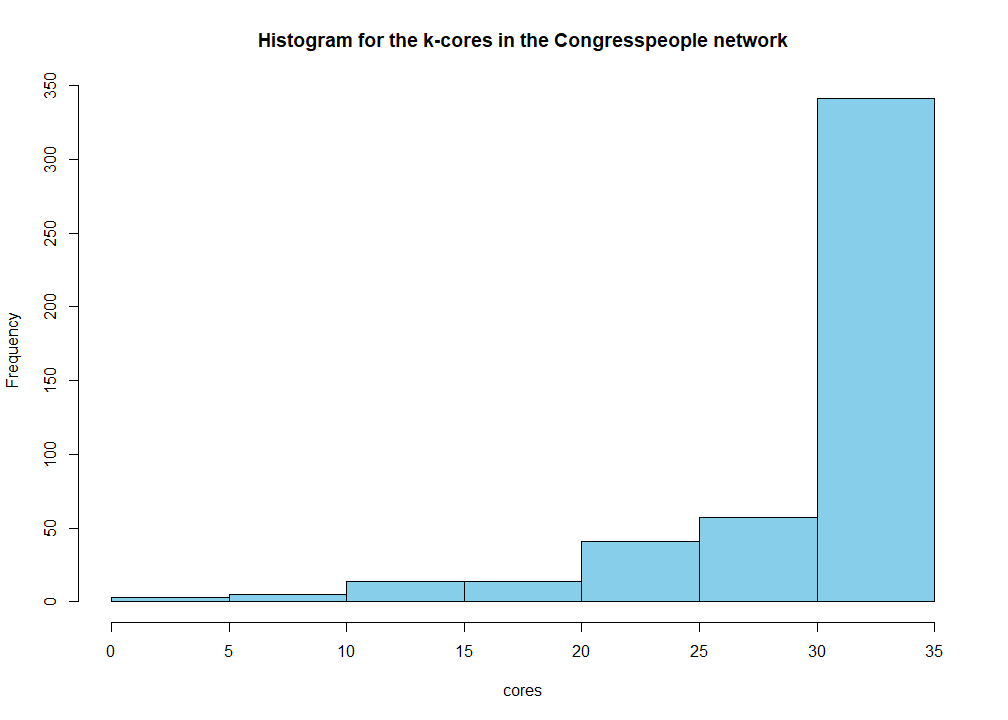

```r
hist(cores,col='skyblue',
     main="Histogram for the k-cores in the Congresspeople network")
```

Firstly, we can see that the scarcity of vertices with low coreness values suggests that there are relatively few peripheral nodes with low connectivity or influence in the network. Instead, a large proportion of nodes appear to be rightly positioned, with higher coreness values indicating greater centrality and connectivity as we know.

Moreover, the sharp increase in the number of vertices with coreness values in the range of 30-35 indicates the formation of a core group of highly central nodes (the one we have been guessing). These nodes likely represent key influencers within the congresspeople network. The concentration of vertices with high coreness values suggests a cohesive network structure characterized by dense connections and strong interdependencies among nodes. This cohesion fosters efficient communication and facilitates the spread of information or influence across the network.

Finally, we generate the subgraph of our original graph containing only the vertices with the maximum coreness value (the highly central nodes), and then we extract the unique edges from that subgraph and display some of them.

```r
subgraph <- induced_subgraph(g, which(cores == max(cores)))
unique(E(subgraph))
```

```
## + 3100/3100 edges from 104fe53 (vertex names):
##  [1] Tammy Baldwin->John Barrasso          Tammy Baldwin->Michael Bennet
##  [3] Tammy Baldwin->Marsha Blackburn       Tammy Baldwin->Richard Blumenthal
##  [5] Tammy Baldwin->Roy Blunt              Tammy Baldwin->Cory Booker
##  [7] Tammy Baldwin->John Boozman           Tammy Baldwin->Mike Braun
##  [9] Tammy Baldwin->Sherrod Brown          Tammy Baldwin->Maria Cantwell
## [11] Tammy Baldwin->Shelley Moore Capito   Tammy Baldwin->Ben Cardin
## [13] Tammy Baldwin->Tom Carper             Tammy Baldwin->Bob Casey Jr.
## [15] Tammy Baldwin->Bill Cassidy           Tammy Baldwin->Chris Coons
## [17] Tammy Baldwin->John Cornyn            Tammy Baldwin->Catherine Cortez Masto
## [19] Tammy Baldwin->Tom Cotton             Tammy Baldwin->Kevin Cramer
## + ... omitted several edges
```

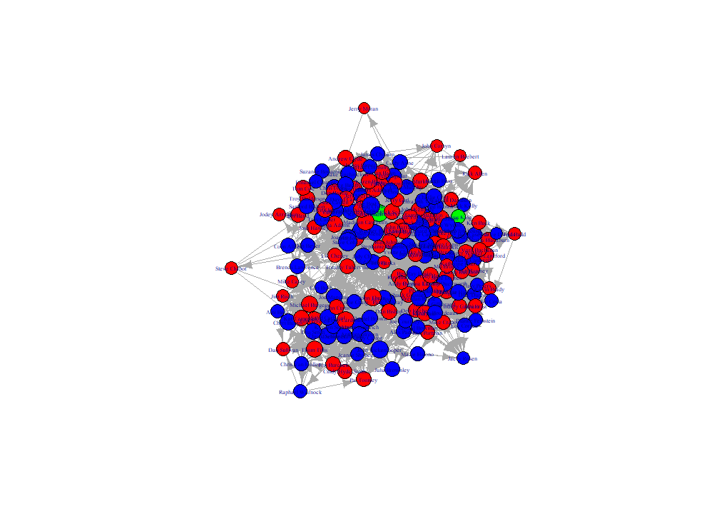

```r
plot(subgraph, vertex.label.cex = 0.5, layout = layout_nicely, margin = 0.2, vertex.dist = 5.5)
```

Not very useful because we cannot see the network well. We have said that it shows that the graph may be dense, but we are going to compute its density to check.

### 4.3.3 Density

Edge density is a measure used in graph theory to quantify how densely connected the vertices are within a graph. It represents the ratio of the actual number of edges in the graph to the total possible number of edges.

The formula for edge density is:

$$\text{den(G)} = \frac{L}{N(N-1)},$$

where $L$ is the number of edges in the graph $G$ and $N$ is the number of vertices in the graph $G$. Hence, the denominator $N(N-1)$ represents the total possible number of edges in our directed graph with $N$ vertices, since $N(N-1)$ represents all possible ordered pairs of $N$ vertices.

The density value spans from $0$ to $1$, reflecting the degree of connectivity within the graph. A density of $0$ signifies a sparse graph, indicating that the vertices are minimally connected, with numerous isolated components scattered throughout the graph. Conversely, a density of $1$ denotes a dense graph, where every possible edge is present, showcasing a high level of interconnectedness among the vertices and an abundance of direct connections linking them together.

```r
edge_density(g)
```

```
## [1] 0.05902287
```

We know look at how densely surrounded are a couple of previously mentioned vertices, Mike Gallagher and Bernie Sanders, by using their their ego networks. An ego network is a subgraph of the original graph, where the ego is the central node, and the alters are the neighboring nodes directly connected to the ego.

Firstly, we create an ego network centered around Mike Gallagher and, the, we calculate the edge density of that ego network. This edge density value provides insights into the level of connectivity within the ego network, specifically focusing on the connections involving “Mike Gallagher” and the vertices within a distance of 1 from him in the original graph.

```r
ego_mike_gallagher <- make_ego_graph(g,order=1,nodes=V(g)[212])
edge_density(ego_mike_gallagher[[1]])
```

```
## [1] 0.1196042
```

The edge density is approximately $0.1196$. This suggests that the connections within this ego network are relatively sparse, with approximately $11.96%$ of the possible connections being present. This indicates that Mike Gallagher and the vertices within one hop of him are not extensively connected, with several potential edges remaining unutilized.

We do the same with Bernie Sanders to be able to compare them.

```r
ego_bernie_sanders <- make_ego_graph(g,order=1,nodes=V(g)[71])
edge_density(ego_bernie_sanders[[1]])
```

```
## [1] 0.1484848
```

The edge density is now approximately 0.1485, indicating a slightly higher density compared to Mike Gallagher’s ego network, with approximately 14.85% of the possible connections present. The connections within this ego network are relatively denser, implying a higher level of connectivity among Bernie Sanders and the vertices within one hop of him. Bernie Sanders is more densely surrounded than Mike Gallagher, even though we observed that Mike Gallagher was more influential.

### 4.3.4 Clustering coefficient (transitivity)

We will measure the density of the graph in an alternative way. Density of triangles among connected triplets is going to be taken into consideration.

A triplet is a subgraph of three vertices connected by at least two edges. We denote $\tau_{\triangle}(G)$ the number of closet triplets (triangles) in a graph and $\tau_3(G)$ the number of all triplets in a graph. Then, the clustering coefficient or transitivity of a graph is

$$cl(G)=3\frac{\tau_{\triangle}(G)}{\tau_3(G)}$$

Transitivity values lie between 0 and 1, providing a measure of global clustering. For this, undirected networks are considered instead of directed.

```r
transitivity(g,type="global")
```

```
## [1] 0.269535
```

We see that the network is not very dense, thus, the relative frequency of triplets close to form triangles is not very high.

## 4.4 Connectivity

### 4.4.1 Components

We obtain the number of components of the network. First, we consider the weak case. We have a single components in this case, as we saw in a previous work. Thus, our network is weakly connected, where the component is the whole network.

```r
comps_weak <- components(g,mode="weak")
comps_weak$no
```

```
## [1] 1
```

```r
comps_weak$csize
```

```
## [1] 475
```

For the strong case, we have 7 components. However, if we check the size of the components, we see that we have a components of size $469$ and the rest of the components have size 1, thus they are isolated vertices. The big component represents $98.7%$ of the total number of congresspeople.

```r
comps_strong <- components(g,mode="strong")
comps_strong$no
```

```
## [1] 7
```

```r
comps_strong$csize
```

```
## [1]   1   1   1   1   1   1 469
```

```r
table(comps_strong$csize)
```

```
##
##   1 469
##   6   1
```

```r
max(comps_strong$csize)/vcount(g)
```

```
## [1] 0.9873684
```

```r
gc <- induced_subgraph(g,vids=V(g)[comps_strong$membershi==7])
gc
```

```
## IGRAPH 11ef8c2 DNW- 469 13187 --
## + attr: name (v/c), gender (v/x), affiliation (v/x), color (v/c), size
## | (v/n), weight (e/n)
## + edges from 11ef8c2 (vertex names):
##  [1] Tammy Baldwin->John Barrasso        Tammy Baldwin->Michael Bennet
##  [3] Tammy Baldwin->Marsha Blackburn     Tammy Baldwin->Richard Blumenthal
##  [5] Tammy Baldwin->Roy Blunt            Tammy Baldwin->Cory Booker
##  [7] Tammy Baldwin->John Boozman         Tammy Baldwin->Mike Braun
##  [9] Tammy Baldwin->Sherrod Brown        Tammy Baldwin->Maria Cantwell
## [11] Tammy Baldwin->Shelley Moore Capito Tammy Baldwin->Ben Cardin
## [13] Tammy Baldwin->Tom Carper           Tammy Baldwin->Bob Casey Jr.
## + ... omitted several edges
```

```r
mean_distance(gc, weights = 1 / E(gc)$weight)
```

```
## [1] 395.1467
```

```r
transitivity(gc)
```

```
## [1] 0.2710319
```

### 4.4.2 Vertex and edge connectivity

Vertex connectivity refers to the minimum number of vertices that need to be removed in order to disconnect the graph. Edge connectivity is the minimum number of edges that need to be removed in order to disconnect the graph.

In both cases, we obtain that the minimum number of vertices/edges to be removed is 1.

If we look at the articulation points, we see that there are not single vertices that disconnect the network.

```r
vertex_connectivity(gc)
```

```
## [1] 1
```

```r
edge_connectivity(gc)
```

```
## [1] 1
```

```r
art_gc <- articulation_points(gc)
art_gc
```

```
## + 0/469 vertices, named, from 11ef8c2:
```

# 5 Assignment 5

## 5.1 Community Detection Methods

A central issue to social network analysis is that of understanding the pattern of relations between individuals of the network. Through said study, there can be group of individuals that interact more closer or stronger with one another. This groups are usually referred to as communities. In this section several community detection methods will be used on the US Congress influence network.

It is important to remember that out network is directed and not strongly connected, but rather comprised of 7 components out of which 6 are only made up of one vertex, leaving the seventh component to be the giant component. The community detection algorithms carried out here will use the giant component as input.

### 5.1.1 Optimal Modularity

First, we could attempt to start with the optimal modularity community detection method, which maximizes the modularity over all possible partitions of the network. Unfortunately, considering the size of our network ($N=475$), this is too computationally demanding, and so it has not been possible.

```r
opti.mod = cluster_optimal(gc)
```

### 5.1.2 Fast Greedy

Due to optimal modularity being computationally expensive, a fast greedy algorithm was derived in order to be able to obtain similar solutions (although not necessarily optimal) to those of optimal modularity. This algorithm can be applied even to large networks, so it is possible to use for the network at hand.

```r
greedy = cluster_fast_greedy(as.undirected(gc))
```

```r
k.greedy = length(greedy)
k.greedy
```

```
## [1] 5
```

The Fast Greedy algorithm has found a total of five communities within the US Congress network.

```r
sizes(greedy)
```

```
## Community sizes
##   1   2   3   4   5
## 202  88 164  13   2
```

The size of said communities varies greatly, with the two biggest networks taking up more than one third of all the Congresspeople each, and the smallest one being made up of only 2 individuals.

We can also check the modularity attained by this partition:

```r
mod.greedy = modularity(greedy)
mod.greedy
```

```
## [1] 0.4381604
```

Finally, we can visualize the communities superimposed on the network.

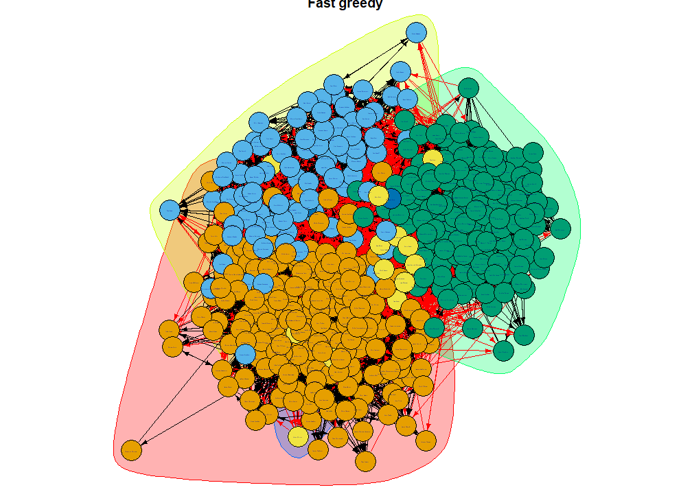

```r
par(mar=c(0,0,0,0)+.3)
plot(greedy, gc, main="Fast greedy", vertex.size=10, vertex.label.cex=0.001, edge.labels=data$weight,
     edge.arrow.size=0.5)
```

Although a bit difficult to fully distinguish due to the size of the network, there are clearly two better defined communities, in which most of the nodes are close to each other, which correspond to the two biggest. The third biggest one is somewhat clear, while the smallest ones seems to be made up of those vertices which are perhaps more isolated. In any case, the amount of red arrows indicates that there is a lot of influence trade-off between different commmunities.

### 5.1.3 Louvain

Next, the Louvain algorithm can be used. This algorithm runs hierarchically from local to global communities looking for optimal modularity. Furtheremore, it does so in a fast way, so that there is no problem applying it to this network.

```r
louvain = cluster_louvain(as.undirected(gc))
```

```r
k.louvain = length(louvain)
k.louvain
```

```
## [1] 6
```

```r
sizes(louvain)
```

```
## Community sizes
##   1   2   3   4   5   6
## 196  82   7 158   8  18
```

The modularity of the partition can also be checked:

```r
mod.louvain = modularity(louvain)
mod.louvain
```

```
## [1] 0.43252
```

We can also visualize the partition:

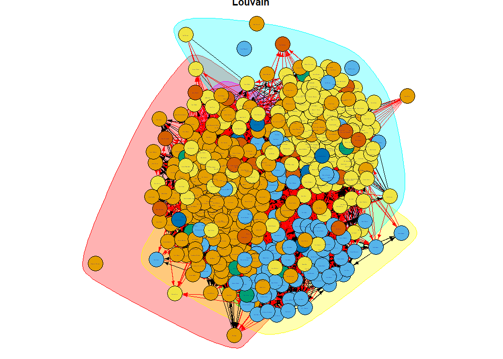

```r
par(mar=c(0,0,0,0)+.3)
plot(louvain, g, main="Louvain", vertex.size=10, vertex.label.cex=0.001, edge.labels=data$weight,
     edge.arrow.size=0.5)
```

In this case, no community seems to be overly clearly-defined in the visualization.

### 5.1.4 Label Propagation

Another community detection algorithm that can be run on large networks is that of label propagation, which decides the community of each vertex taking into account the communities of its neighbors. Note that this algorithm has the option to take into account the direction of a network for the label propagation. It is also worth mentioning that the algorithm needs an initial label assignation for the vertices, which can be random although that sometimes leads to worse results, so the label assignation obtained through the Louvain algorithm has been used an initial state.

```r
label = cluster_label_prop(gc, mode="out", initial=as.vector(membership(louvain)))
```

```r
k.label = length(label)
k.label
```

```
## [1] 2
```

```r
sizes(label)
```

```
## Community sizes
##   1   2
## 314 155
```

The modularity of this partition can be checked:

```r
mod.label = modularity(label)
mod.label
```

```
## [1] 0.3687864
```

Note that this modularity is the smallest one seen so far and, in particular, is much worse than that of the initial state given by the output of the Louvain algorithm.

The communities can be visualized:

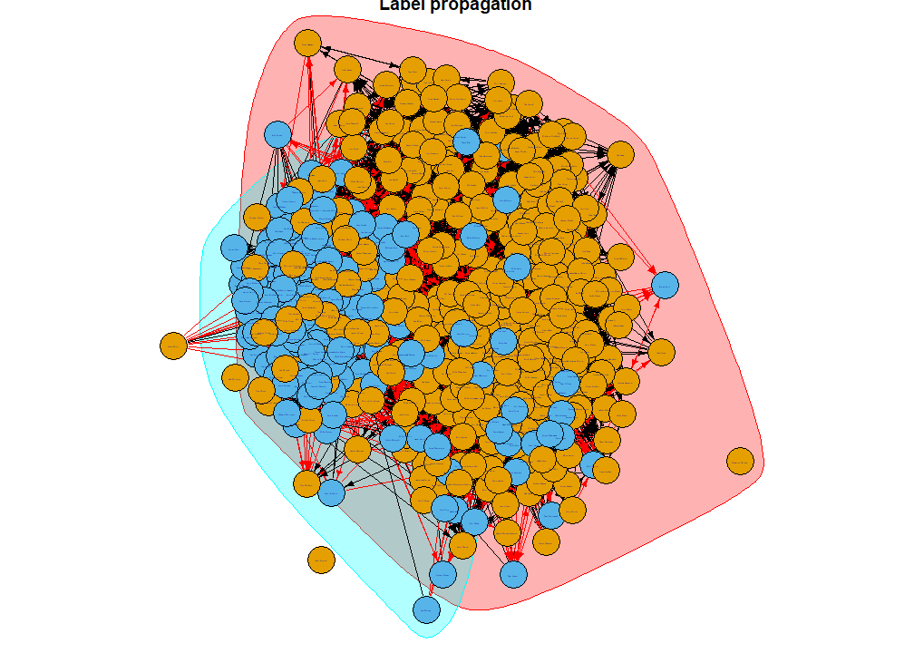

```r
par(mar=c(0,0,0,0)+.3)
plot(label, g, main="Label propagation", vertex.size=10, vertex.label.cex=0.001, edge.labels=data$weight,
     edge.arrow.size=0.5)
```

Once again, we observe two somewhat well defined communities.

### 5.1.5 Edge Betweenness

Just like the optimal modularity community detection algorithm, the edge betweennes community detection algorithm is extremely labour intensive and so becomes incredibly computationally expensive as the size of the network increases. Such is the case that it has not been possible to run it for the US Congress network.

```r
edge = cluster_edge_betweenness(gc, directed=T, weights=1/E(gc)$weight)
```

### 5.1.6 Walktrap

Finally, the last community detection algorithm studied in this section will be the Walktrap algorithm. This method uses hierarchical clustering by defining a certain distance between the vertices of the network related to the probabilities of random walks.

```r
walktrap = cluster_walktrap(gc)
```

```r
k.walktrap = length(walktrap)
k.walktrap
```

```
## [1] 4
```

```r
sizes(walktrap)
```

```
## Community sizes
##   1   2   3   4
## 196 166  64  43
```

The Walktrap algorithm detects a total of four communities in this network. The sizes of the communities is somewhat more balanced, with two big communities and two small communities of similar sizes.

As always, it is important to check the modularity of the partition.

```r
mod.walktrap = modularity(walktrap)
mod.walktrap
```

```
## [1] 0.4363918
```

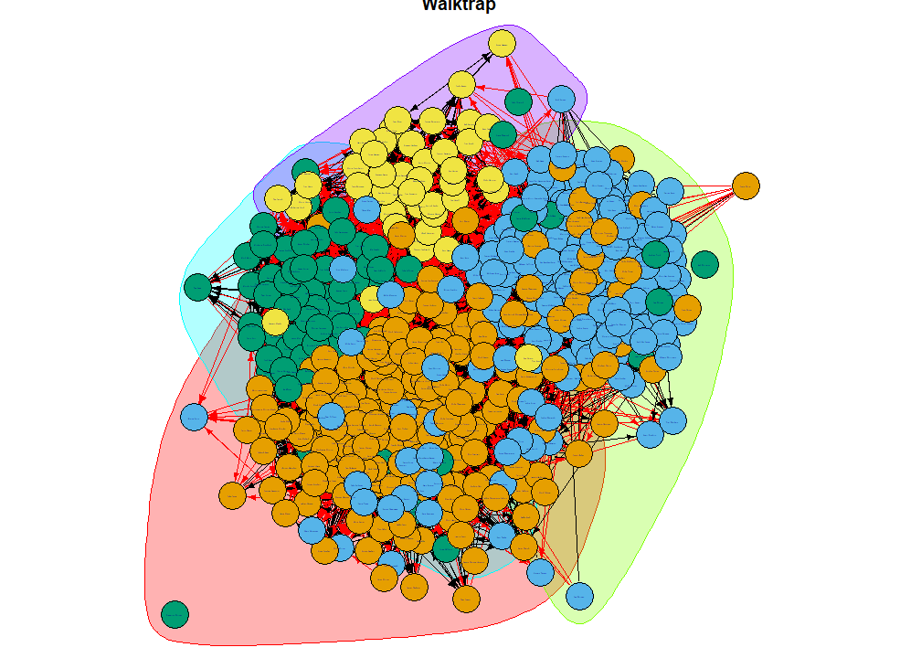

```r
par(mar=c(0,0,0,0)+.3)
plot(walktrap, g, main="Walktrap", vertex.size=10, vertex.label.cex=0.001, edge.labels=data$weight,
     edge.arrow.size=0.5)
```

### 5.1.7 Conclusion

The results of the different algorithms are:

```r
data.frame(
  row.names=c("K", "Modularity"),
  Greedy=c(k.greedy, mod.greedy),
  Louvain=c(k.louvain, mod.louvain),
  Label=c(k.label, mod.label),
  Walktrap=c(k.walktrap, mod.walktrap)
)
```

|  | Greedy | Louvain | Label | Walktrap |
| --- | --- | --- | --- | --- |
| K | 5.0000000 | 6.00000 | 2.0000000 | 4.0000000 |
| Modularity | 0.4381604 | 0.43252 | 0.3687864 | 0.4363918 |

```r
sizes(louvain)
```

```
## Community sizes
##   1   2   3   4   5   6
## 196  82   7 158   8  18
```

The visualization of said communities is:

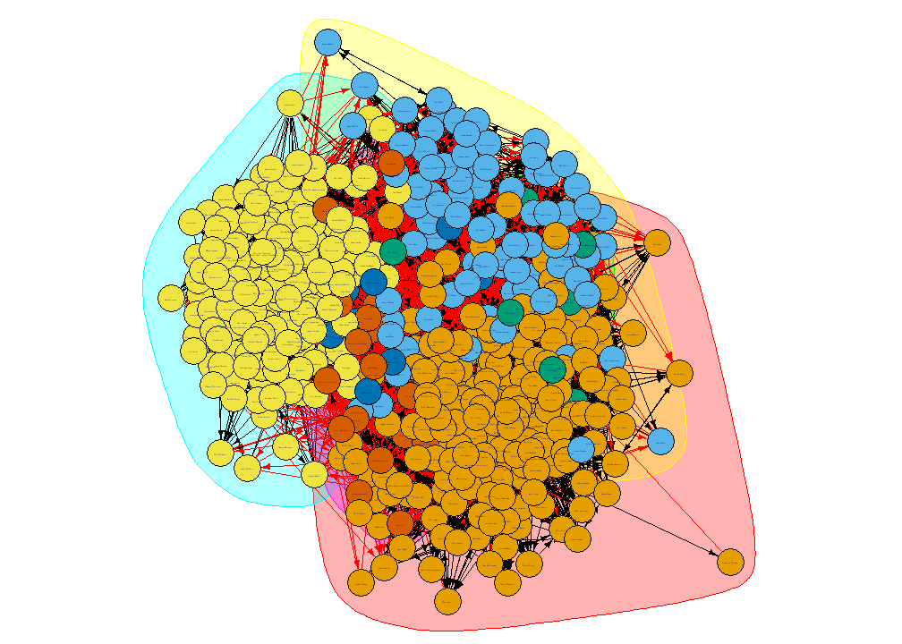

```r
par(mar=c(0,0,0,0)+.3)
plot(louvain, gc, vertex.size=10, vertex.label.cex=0.001, edge.labels=data$weight,
     edge.arrow.size=0.5)
```

## 5.2 Assortativity coefficient

A different way to characterize network cohesion is through the assortativity coefficient. It is a measure of the relationships between influencers, that is, whether they avoid each other or they link preferably with each other, leaving small-degree vertices to connect with other small-degree vertices.

Before calculating the assortativity coefficient, it is useful to take a look at the degree pairs of the network:

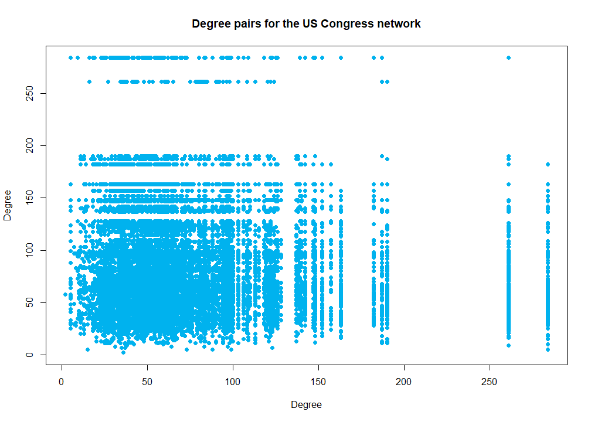

```r
degrees <- degree(g)
g_degrees <- matrix(NA,nrow=ecount(g),ncol=2)
edges_g <- as_edgelist(g)
for (i in 1:ecount(g)){
  g_degrees[i,] = degrees[edges_g[i,]]
}
color_1 = "deepskyblue2"
plot(g_degrees,pch=19, col=color_1, main="Degree pairs for the US Congress network",
     xlab="Degree",ylab="Degree")
```

We can compute the assortativity coefficient:

```r
assortativity_degree(g)
```

```
## [1] -0.09621433
```

A coefficient of -0.09 such as the one computed by this network indicates that the US Congress influence network is neutral, that is, the number of edges between the influencers coincides with what would be expected from chance.

## 5.3 Number of communities

In this part f the work, we will be focusing on generalized random graph models. A generalized random graph network is going to be generated with the same order as our cogress network, specifically , $N=475$. The degree distribution is also the same, leaving us with a network of size $L=13289$.

```r
set.seed(1234)
in_degree <- degree(g, mode = "in", loops = FALSE)
out_degree <- degree(g, mode = "out", loops = FALSE)
is_simple(g)
```

```
## [1] FALSE
```

```r
G_congress <-sample_degseq(out.deg=out_degree,in.deg=in_degree,method="simple")
```

Note that the networks have $475$ vertices and $13289$ edges as the original ones.

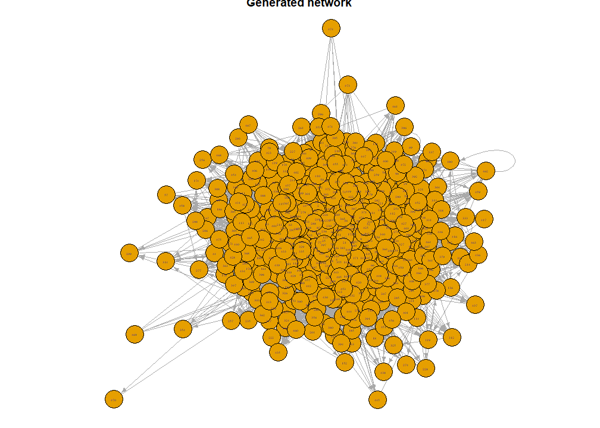

```r
set.seed(1234)
par(mar=c(0,0,0,0)+.3)
plot(G_congress, vertex.size=10, vertex.label.cex=0.3, edge.arrow.size=0.5, main="Generated network")
```

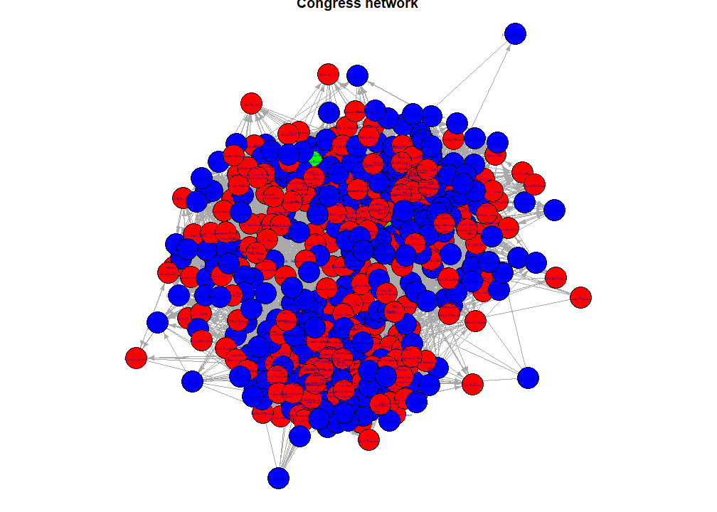

```r
par(mar=c(0,0,0,0)+.3)
plot(g, vertex.size=10, vertex.label.cex=0.3, edge.arrow.size=0.5, main="Congress network")
```

As we can see below, the degree distribution is also the same fro the generated and the original network.

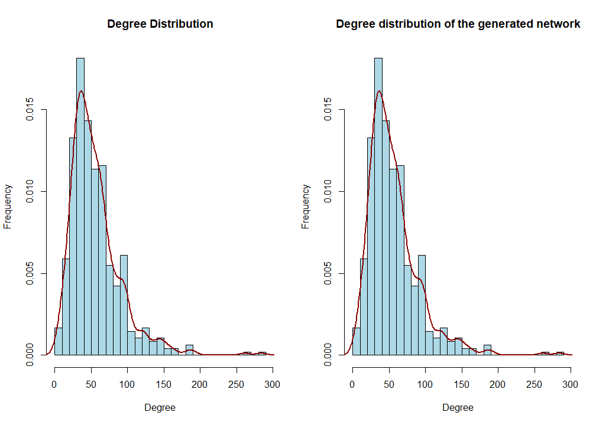

```r
par(mfrow=c(1,2))
degrees <- degree(g, mode = "total")
hist(degrees, breaks = 30, main = "Degree Distribution",
     xlab = "Degree", ylab = "Frequency", freq=F, col="lightblue")
lines(density(degrees),col="darkred", lwd=2.5)
degrees_G <- degree(G_congress, mode = "total")
hist(degrees_G, breaks = 30, main = "Degree distribution of the generated network",
     xlab = "Degree", ylab = "Frequency", freq=F, col="lightblue")
lines(density(degrees_G),col="darkred", lwd=2.5)
```

Next, we obtain some of the main characteristics of the two networks such as the average path length, the diameter, the density, the clustering coefficient, the number of components and the size of the network components.Similarities can be observed between the two networks.

```r
c(mean_distance(g),mean_distance(G_congress))
```

```
## [1] 0.00640717 2.25476145
```

```r
#weighted and non weighted
c(diameter(g),diameter(G_congress))
```

```
## [1] 0.03076809 5.00000000
```

```r
c(edge_density(g),edge_density(G_congress))
```

```
## [1] 0.05902287 0.05902287
```

```r
c(transitivity(g),transitivity(G_congress))
```

```
## [1] 0.2695350 0.1690327
```

```r
compsG<-components(G_congress, mode="weak")
compsG$csize
```

```
## [1] 475
```

```r
compsG$no
```

```
## [1] 1
```

```r
compsG_strong<-components(G_congress, mode="strong")
compsG_strong$csize
```

```
## [1]   1   1   1   1   1   1 469
```

```r
compsG_strong$no
```

```
## [1] 7
```

### 5.3.1 Number of communities in a network

We run four community detection algorithms: fast greedy, Louvain, label propagation and walktrap. We won’t consider optimal modularity because of its high computational cost to carry out the next steps of the analysis. We will omit weights for the sake of simplicity.

```r
set.seed(1234)
options(warn=-1)
fg <- cluster_fast_greedy(as.undirected(g),weights=rep(1,10222))
length(fg)
```

```
## [1] 3
```

```r
lo <- cluster_louvain(as.undirected(g),weights=rep(1,10222))
length(lo)
```

```
## [1] 4
```

```r
lp <- cluster_label_prop(g,initial=as.vector(membership(lo)),mode="out",weights=rep(1,13289))
length(lp)
```

```
## [1] 3
```

```r
wa <- cluster_walktrap(g,weights=rep(1,13289))
length(wa)
```

```
## [1] 3
```

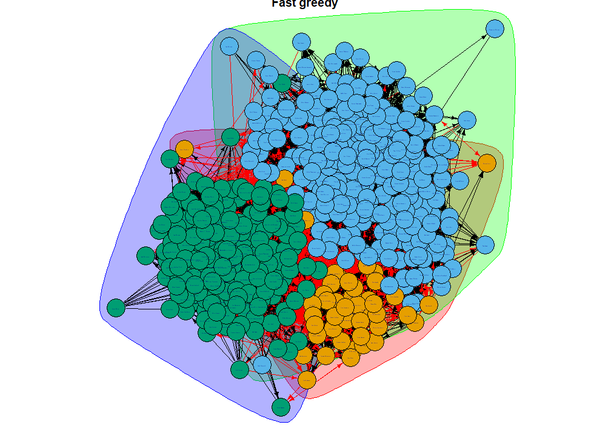

```r
options(warn=0)
par(mar=c(0,0,0,0)+.3)
plot(fg, g, main="Fast greedy", vertex.size=10, vertex.label.cex=0.001,edge.arrow.size=0.5)
```

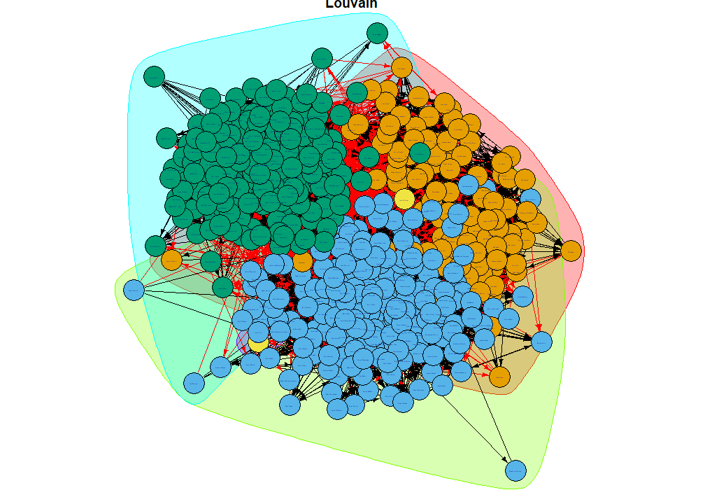

```r
par(mar=c(0,0,0,0)+.3)
plot(lo,g,main="Louvain", vertex.size=10, vertex.label.cex=0.001,edge.arrow.size=0.5)
```

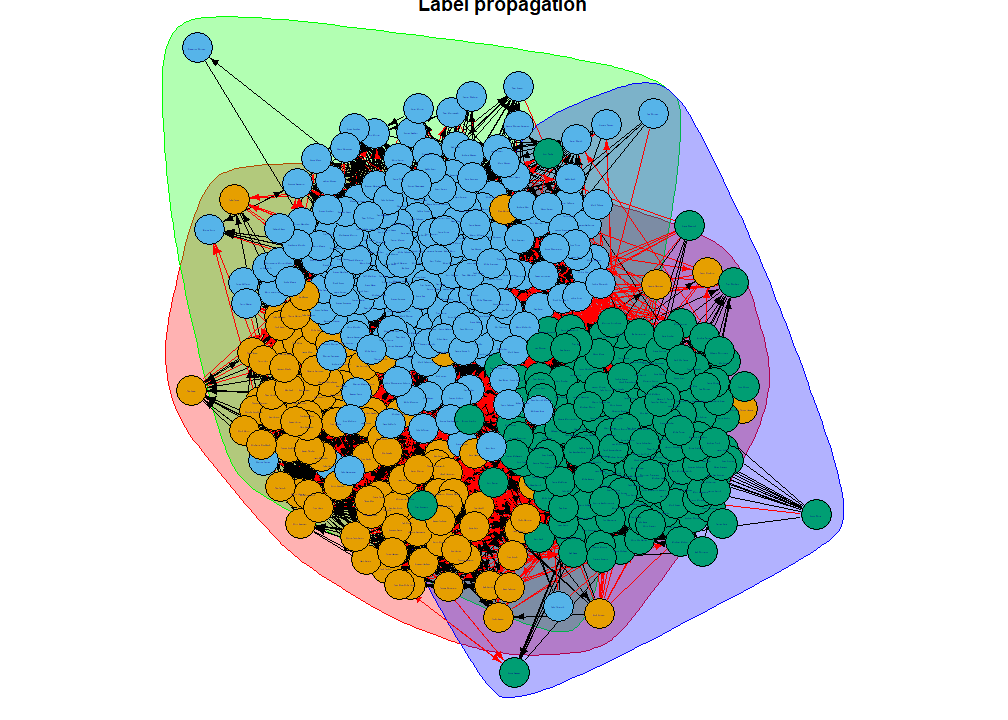

```r
par(mar=c(0,0,0,0)+.3)
plot(lp,g,main="Label propagation", vertex.size=10, vertex.label.cex=0.001,edge.arrow.size=0.5)
```

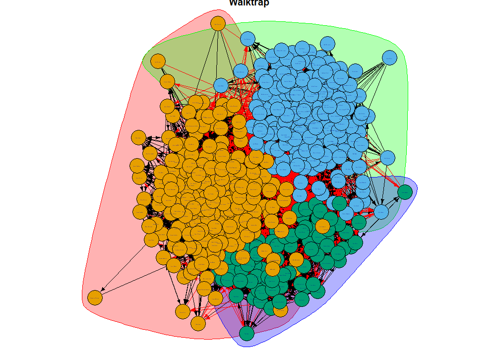

```r
par(mar=c(0,0,0,0)+.3)
plot(wa,g,main="Walktrap", vertex.size=10, vertex.label.cex=0.001,edge.arrow.size=0.5)
```

```r
set.seed(1234)
N <- vcount(g)
L <- ecount(g)
n_trials <- 10000
num_comm_ER_fg <- vector(mode="numeric",length=n_trials)
num_comm_ER_lo <- vector(mode="numeric",length=n_trials)
num_comm_ER_lp <- vector(mode="numeric",length=n_trials)
num_comm_ER_wa <- vector(mode="numeric",length=n_trials)
options(warn=-1)
for (i in 1 : n_trials){
  ER <- sample_gnm(n=N,m=L,directed=TRUE)
  cl_ER_fg <- cluster_fast_greedy(as.undirected(ER))
  num_comm_ER_fg[i] <- length(cl_ER_fg)
  cl_ER_lo <- cluster_louvain(as.undirected(ER))
  num_comm_ER_lo[i] <- length(cl_ER_lo)
  cl_ER_lp <- cluster_label_prop(ER,initial=as.vector(membership(cl_ER_lo)))
  num_comm_ER_lp[i] <- length(cl_ER_lp)
  cl_ER_wa <- cluster_walktrap(ER)
  num_comm_ER_wa[i] <- length(cl_ER_wa)
}
options(warn=0)
```

Next, we use the degree sequence and use the generalized random graph moel to generate $10000$ networks.

Then, for each network, we run the four community detection algorithms and select the number of communities detected by each of them.

```r
set.seed(1234)
num_comm_G_fg <- vector(mode="numeric",length=n_trials)
num_comm_G_lo <- vector(mode="numeric",length=n_trials)
num_comm_G_lp <- vector(mode="numeric",length=n_trials)
#num_comm_G_eb <- vector(mode="numeric",length=n_trials)
num_comm_G_wa <- vector(mode="numeric",length=n_trials)
options(warn=-1)
for (i in 1 : n_trials){
  G_congress<-sample_degseq(out.deg=out_degree,in.deg=in_degree,method="simple")
  cl_G_congress_fg <- cluster_fast_greedy(as.undirected(G_congress))
  num_comm_G_fg[i] <- length(cl_G_congress_fg)
  cl_G_congress_lo <- cluster_louvain(as.undirected(G_congress))
  num_comm_G_lo[i] <- length(cl_G_congress_lo)
  cl_G_congress_lp <- cluster_label_prop(G_congress,
                    initial=as.vector(membership(cl_G_congress_lo)))
  num_comm_G_lp[i] <- length(cl_G_congress_lp)
  cl_G_congress_wa <- cluster_walktrap(G_congress)
  num_comm_G_wa[i] <- length(cl_G_congress_wa)
}
options(warn=0)
```

Afterwards, we compare the results obtained with each community detection for the two experiments using barplots.

```r
comm_ER_G_fg <- c(num_comm_ER_fg,num_comm_G_fg)
ind_comm_ER_G_fg <- c(rep(1,n_trials),rep(2,n_trials))
freqs_comm_ER_G_fg <- table(ind_comm_ER_G_fg,comm_ER_G_fg) / n_trials
freqs_comm_ER_G_fg
```

```
##                 comm_ER_G_fg
## ind_comm_ER_G_fg      3      4      5      6      7
##                1 0.2024 0.7211 0.0759 0.0006 0.0000
##                2 0.0111 0.5252 0.4087 0.0530 0.0020
```

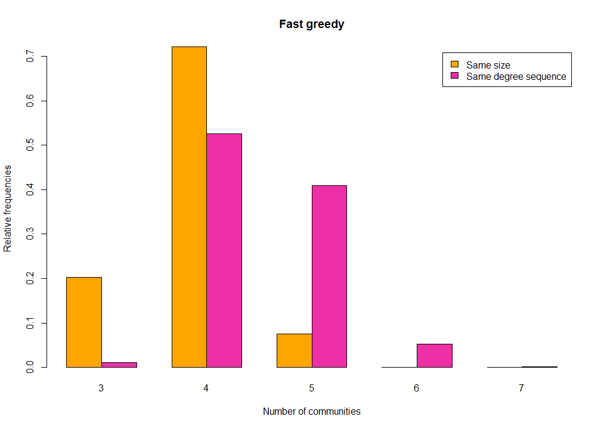

```r
color_1 <- "orange"
color_2 <- "maroon2"
barplot(freqs_comm_ER_G_fg,beside=TRUE,col=c(color_1,color_2),
        main="Fast greedy",
        xlab="Number of communities",ylab="Relative frequencies",
        legend=c("Same size","Same degree sequence"))
```

Fast greedy selected 3 communities, however the barplot suggests that 3 has low frequency, so that it seems that this solution is not appropriate, suggesting 4 as a bettre solution.

```r
comm_ER_G_lo <- c(num_comm_ER_lo,num_comm_G_lo)
ind_comm_ER_G_lo <- c(rep(1,n_trials),rep(2,n_trials))
freqs_comm_ER_G_lo <- table(ind_comm_ER_G_lo,comm_ER_G_lo) / n_trials
freqs_comm_ER_G_lo
```

```
##                 comm_ER_G_lo
## ind_comm_ER_G_lo      6      7      8      9     10     11     12     13
##                1 0.0008 0.0345 0.2476 0.4270 0.2358 0.0503 0.0040 0.0000
##                2 0.0025 0.0737 0.3318 0.4046 0.1621 0.0237 0.0014 0.0002
```

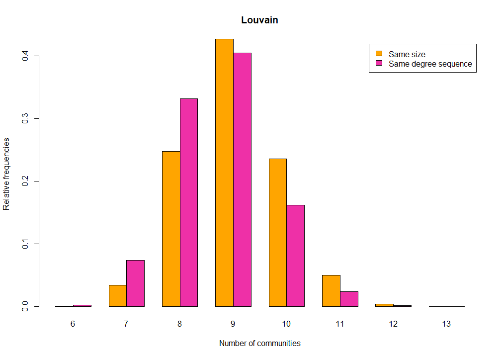

```r
barplot(freqs_comm_ER_G_lo,beside=TRUE,col=c(color_1,color_2),
        main="Louvain",
        xlab="Number of communities",ylab="Relative frequencies",
        legend=c("Same size","Same degree sequence"))
```

Louvain selected 4 communities and the barplot suggests that 4 has hardly no frequency. So 4 might not be an appropriate number of communities.

```r
comm_ER_G_lp <- c(num_comm_ER_lp,num_comm_G_lp)
ind_comm_ER_G_lp <- c(rep(1,n_trials),rep(2,n_trials))
freqs_comm_ER_G_lp <- table(ind_comm_ER_G_lp,comm_ER_G_lp) / n_trials
freqs_comm_ER_G_lp
```

```
##                 comm_ER_G_lp
## ind_comm_ER_G_lp      1      2      3      4      5      6      7
##                1 1.0000 0.0000 0.0000 0.0000 0.0000 0.0000 0.0000
##                2 0.0000 0.0031 0.0622 0.2975 0.4181 0.1939 0.0252
```

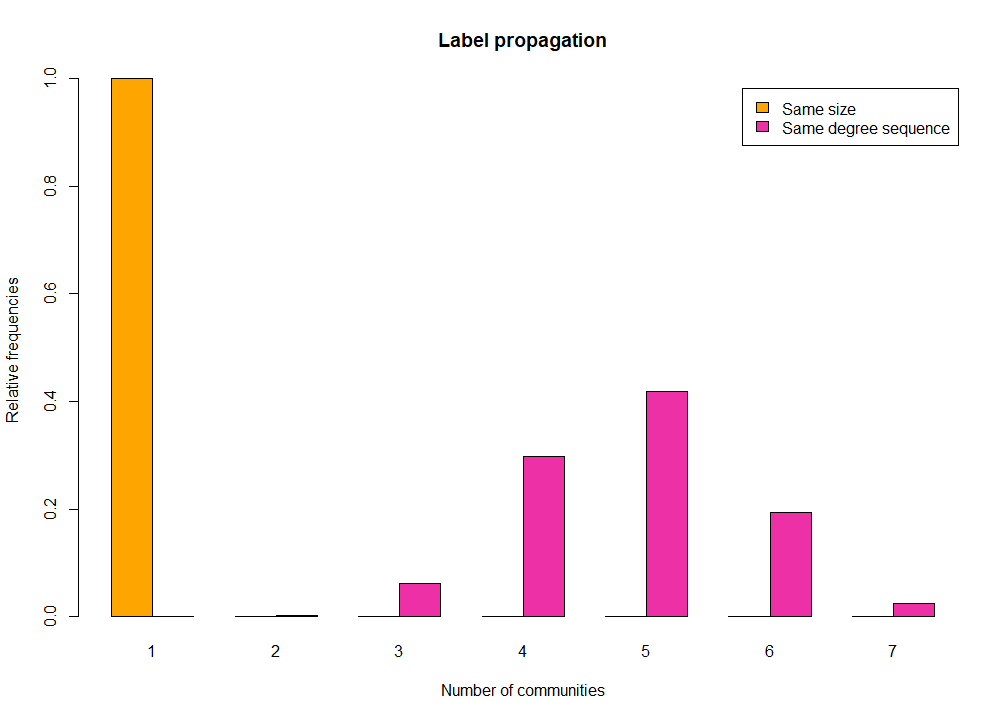

```r
barplot(freqs_comm_ER_G_lp,beside=TRUE,col=c(color_1,color_2),
        main="Label propagation",
        xlab="Number of communities",ylab="Relative frequencies",
        legend=c("Same size","Same degree sequence"))
```

Label propagation selected 3 communities, which according to be barplot it is not particularly clear in which number of communities to select.

```r
comm_ER_G_wa <- c(num_comm_ER_wa,num_comm_G_wa)
ind_comm_ER_G_wa <- c(rep(1,n_trials),rep(2,n_trials))
freqs_comm_ER_G_wa <- table(ind_comm_ER_G_wa,comm_ER_G_wa) / n_trials
freqs_comm_ER_G_wa
```

```
##                 comm_ER_G_wa
## ind_comm_ER_G_wa      3      4      5      6      7      8      9     10     11
##                1 0.0020 0.0373 0.1657 0.2568 0.2425 0.1563 0.0850 0.0335 0.0131
##                2 0.0000 0.0000 0.0000 0.0000 0.0000 0.0001 0.0006 0.0009 0.0022
##                 comm_ER_G_wa
## ind_comm_ER_G_wa     12     13     14     15     16     17     18     19     20
##                1 0.0055 0.0017 0.0004 0.0002 0.0000 0.0000 0.0000 0.0000 0.0000
##                2 0.0025 0.0036 0.0061 0.0069 0.0093 0.0127 0.0145 0.0158 0.0206
##                 comm_ER_G_wa
## ind_comm_ER_G_wa     21     22     23     24     25     26     27     28     29
##                1 0.0000 0.0000 0.0000 0.0000 0.0000 0.0000 0.0000 0.0000 0.0000
##                2 0.0222 0.0251 0.0265 0.0307 0.0305 0.0319 0.0333 0.0319 0.0370
##                 comm_ER_G_wa
## ind_comm_ER_G_wa     30     31     32     33     34     35     36     37     38
##                1 0.0000 0.0000 0.0000 0.0000 0.0000 0.0000 0.0000 0.0000 0.0000
##                2 0.0351 0.0360 0.0321 0.0353 0.0359 0.0303 0.0303 0.0268 0.0243
##                 comm_ER_G_wa
## ind_comm_ER_G_wa     39     40     41     42     43     44     45     46     47
##                1 0.0000 0.0000 0.0000 0.0000 0.0000 0.0000 0.0000 0.0000 0.0000
##                2 0.0281 0.0237 0.0241 0.0261 0.0245 0.0212 0.0186 0.0170 0.0164
##                 comm_ER_G_wa
## ind_comm_ER_G_wa     48     49     50     51     52     53     54     55     56
##                1 0.0000 0.0000 0.0000 0.0000 0.0000 0.0000 0.0000 0.0000 0.0000
##                2 0.0147 0.0115 0.0121 0.0115 0.0114 0.0090 0.0101 0.0079 0.0068
##                 comm_ER_G_wa
## ind_comm_ER_G_wa     57     58     59     60     61     62     63     64     65
##                1 0.0000 0.0000 0.0000 0.0000 0.0000 0.0000 0.0000 0.0000 0.0000
##                2 0.0054 0.0054 0.0059 0.0052 0.0030 0.0037 0.0037 0.0024 0.0025
##                 comm_ER_G_wa
## ind_comm_ER_G_wa     66     67     68     69     70     71     72     73     74
##                1 0.0000 0.0000 0.0000 0.0000 0.0000 0.0000 0.0000 0.0000 0.0000
##                2 0.0024 0.0019 0.0017 0.0016 0.0021 0.0017 0.0008 0.0008 0.0004
##                 comm_ER_G_wa
## ind_comm_ER_G_wa     75     76     77     78     79     80     81     82     83
##                1 0.0000 0.0000 0.0000 0.0000 0.0000 0.0000 0.0000 0.0000 0.0000
##                2 0.0002 0.0003 0.0005 0.0005 0.0004 0.0003 0.0003 0.0003 0.0001
##                 comm_ER_G_wa
## ind_comm_ER_G_wa     84     85     87     89     91
##                1 0.0000 0.0000 0.0000 0.0000 0.0000
##                2 0.0002 0.0002 0.0001 0.0002 0.0001
```

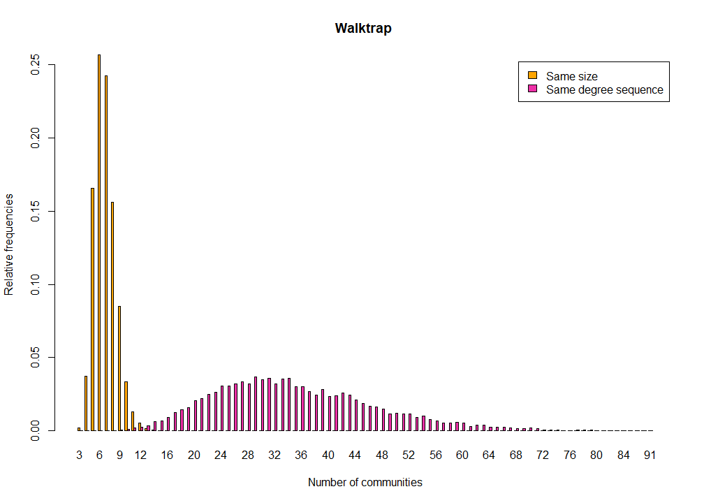

```r
barplot(freqs_comm_ER_G_wa,beside=TRUE,col=c(color_1,color_2),
        main="Walktrap ",
        xlab="Number of communities",ylab="Relative frequencies",
        legend=c("Same size","Same degree sequence"))
```

Here again, the algorithm detected 3 communities. However, even if it is not clear the correct number of communities from the result seen in the barplot, we could say that 3 doesn’t look appropriate.

## 5.4 Small world property

In this final section, we assess whether our congresspeople network has the small world property. Firstly, we are going to use our network to generate a large number of random Erdős-Rényi graphs with the same number of vertices and edges than those of our congresspeople network. Then, for each network we obtain the clustering coefficient and the average path length.

```r
N <- vcount(g)
L <- ecount(g)
n_trials <- 10000
num_tran <- vector(mode="numeric",length=n_trials)
num_ave_path_length <- vector(mode="numeric",length=n_trials)
for (i in 1 : n_trials){
  ER_graph <- sample_gnm(n=N,m=L)
  num_tran[i] <- transitivity(ER_graph)
  num_ave_path_length[i] <- mean_distance(ER_graph)
}
```

Now, we compare the results obtained with those of our network. For that, we compute the clustering coefficient and the average path length of our graph. Firstly, the average path length and, then, the clustering coefficient.

```r
dist <- distances(g, weights = rep(1, L))
mean(dist[lower.tri(dist, diag = FALSE)])
```

```
## [1] 2.063886
```

The average path length of our graph is $2.063886$, indicating that on average, it takes about $2.06$ steps to travel from one vertex to another. This value provides insight into the efficiency of information or signal propagation across the network.

```r
transitivity(g, weights = rep(1, N))
```

```
## [1] 0.269535
```

The clustering coefficient of our graph is $0.269535$, suggesting that there is a moderate level of clustering or local connectivity within our network. This value reflects the tendency of vertices in our graph to form clusters or tightly interconnected groups.

By comparing these values to the average path length and clustering coefficient values obtained from the randomly generated ER graphs, we can assess how our graph’s structural properties differ from those of random networks. The small-world property characterizes networks where most nodes are not neighbors of one another, but most nodes can be reached from every other by a small number of steps, and the clustering coefficient is relatively high compared to random networks.

```r
summary(num_tran)
```

```
##    Min. 1st Qu.  Median    Mean 3rd Qu.    Max.
##  0.1154  0.1176  0.1180  0.1180  0.1184  0.1205
```

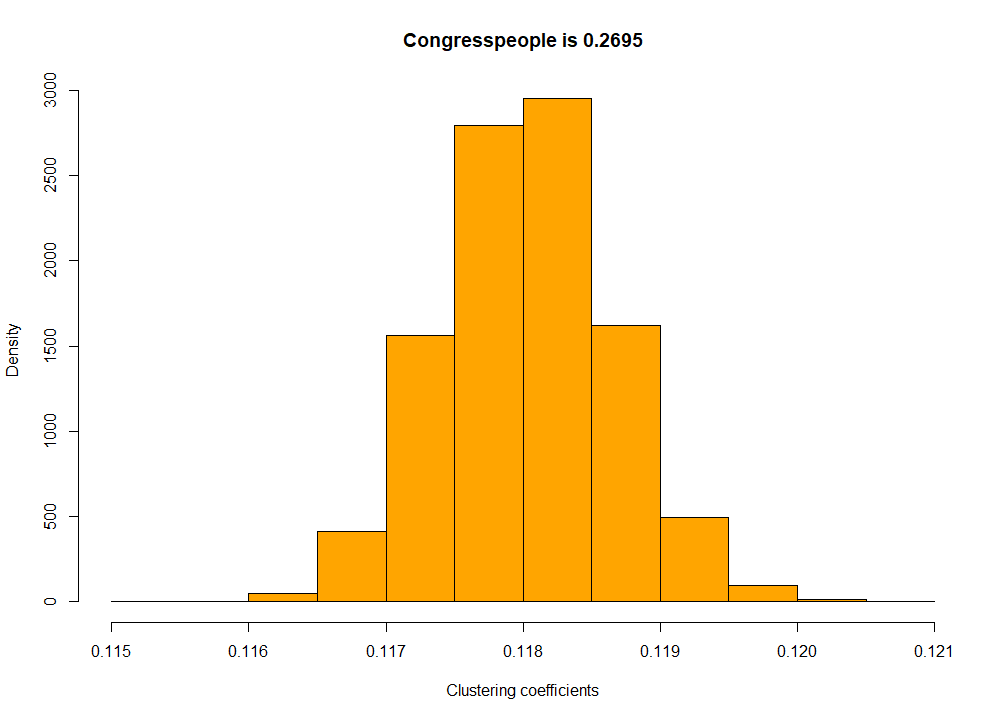

```r
hist(num_tran, col = color_1,
     xlab="Clustering coefficients",ylab="Density",main="Congresspeople is 0.2695")
```

```r
summary(num_ave_path_length)
```

```
##    Min. 1st Qu.  Median    Mean 3rd Qu.    Max.
##   1.883   1.883   1.883   1.883   1.883   1.884
```

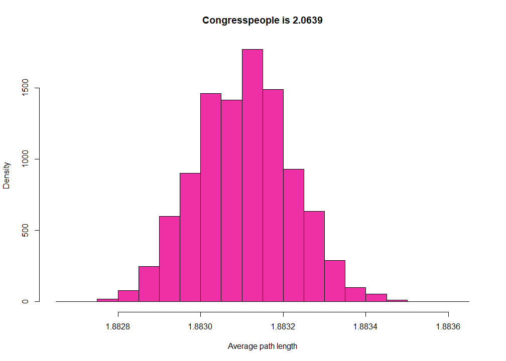

```r
hist(num_ave_path_length, col = color_2,
     xlab="Average path length",ylab="Density",main="Congresspeople is 2.0639")
```

Based on the summary statistics and the histograms for the transitivity (clustering coefficient) and average path length values computed from the randomly generated Erdős-Rényi graphs, we are gonna compare them with the corresponding metrics of our graph to assess whether it exhibits the small-world property.

On one hand, the clustering coefficient values range from approximately 0.1154411 to 0.1205441. Comparing these values to our graph’s clustering coefficient of $0.269535$, we observe that our graph’s clustering coefficient is notably higher than the range of transitivity values obtained from the ER graphs. We can also see this if we look at the histogram; our graph’s value is outside of the histogram’s range to the right. This suggests that our graph has a higher level of clustering or local connectivity than expected in random networks.

On the other hand, the average path length values are all very close to 1.8831002. Comparing these values to our graph’s average path length of $2.063886$, we observe that our graph’s average path length is slightly longer than the values obtained from the ER graphs. However, the difference is relatively small.

Considering these comparisons, our graph exhibits a higher clustering coefficient and a slightly longer average path length compared to randomly generated ER graphs. This combination of characteristics is indicative of the small-world property. Specifically, the higher clustering coefficient suggests the presence of local connectivity, while the relatively short average path length implies efficient global information transfer, both of which are key features of small-world networks. Therefore, based on these metrics, it is likely that our graph possesses the small-world property.